# PBC landmark supermodels on enrollment and attained-age time scales

```r
knitr::opts_chunk$set(
  echo = TRUE,
  message = FALSE,
  warning = FALSE,
  fig.align = "center",
  out.width = "95%"
)
options(width = 110)

prediction_window <- 5
cause_of_interest <- 2L
transplant_code <- 1L
censor_code <- 0L
enrollment_landmarks <- seq(0, 4, by = 1)
confidence_level <- 0.95
n_boot <- getOption("timescale.n_boot", 200L)
bootstrap_seed <- 20260922L
diagnostic_pilot_replicates <- 50L

stopifnot(
  is.numeric(n_boot), length(n_boot) == 1L,
  is.finite(n_boot), n_boot >= 2L, n_boot == as.integer(n_boot)
)
n_boot <- as.integer(n_boot)

library(here)
devtools::load_all(here::here(), quiet = TRUE)
```

# 1 Changes in this version

The version previously reviewed omitted landmark main effects from both supermodels. I added the centered linear and quadratic landmark terms to the enrollment-time supermodel. I kept them out of the primary attained-age model after checking that its prediction windows do not overlap and demonstrating that the Cox partial likelihood cannot estimate those terms on this grid.

I also replaced the coefficient display with robust hazard ratios, confidence intervals, and Wald tests; fitted a separate cause-specific model at every landmark; and compared those disjoint fits with the supermodels in coefficients, precision, and prediction performance. The performance section now separates apparent estimates from subject-level Harrell-bootstrap optimism correction.

# 2 Purpose

I compared the PBC landmark supermodel on two clocks. The enrollment-time analysis asked about risk a given number of years after enrollment. The attained-age analysis asked about risk at a given age. Both used a 5-year prediction window, the same PBC records, outcome, laboratory transformations, and non-age predictors.

These are not competing estimates of the same quantity. An enrollment landmark conditions on survival for a specified time after enrollment; an age landmark conditions on being observed and event-free at a specified age. The risk sets and scientific questions therefore differ. A difference between the fitted models is not bias in either direction.

The age scale is useful when a common time zero has no defensible clinical meaning, as in a cohort assembled from electronic health records. It also requires an additional eligibility rule: a person must have entered observation by the landmark age. I used strict eligibility, `entry <= landmark < exit`, for that reason.

# 3 Source and API checks

I read the function definitions in `R/` and their matching help files in `man/` before setting up the analysis. I then loaded this checkout directly and inspected the formal arguments from the active functions.

```r
api_functions <- list(
  get_pbc_long = get_pbc_long,
  stack_data = stack_data,
  add_interactions = add_interactions,
  dynamic_lm = dynamic_lm,
  dynamic_lm_LMdataframe = getS3method("dynamic_lm", "LMdataframe"),
  predict_dynamicLM = getS3method("predict", "dynamicLM"),
  score = score,
  score_left_truncated = score_left_truncated,
  calplot = calplot
)

api_signatures <- data.frame(
  function_name = names(api_functions),
  arguments = vapply(api_functions, function(fun) {
    argument_names <- names(formals(fun))
    if (length(argument_names)) paste(argument_names, collapse = ", ") else "none"
  }, character(1L)),
  row.names = NULL
)

knitr::kable(api_signatures, col.names = c("Function", "Formal arguments"))
```

| Function | Formal arguments |
| --- | --- |
| get_pbc_long | none |
| stack_data | data, outcome, lms, w, covs, format, id, rtime, left.open, entry, entry_mode |
| add_interactions | lmdata, lm_covs, func_covars, func_lms, keep |
| dynamic_lm | … |
| dynamic_lm_LMdataframe | lmdata, formula, type, method, cluster, x, … |
| predict_dynamicLM | object, newdata, lms, cause, w, extend, silence, complete, … |
| score | object, times, metrics, formula, data, lms, id_col, se.fit, conf.int, contrasts, split.method, B, M, summary, cores, seed, cause, silent, … |
| score_left_truncated | risk, data, time_col, status_col, entry_col, landmark_col, id_col, cause, w, B, seed, conf.int |
| calplot | object, times, formula, data, lms, id_col, split.method, B, M, cores, seed, regression_values, cause, plot, main, … |

The source checks changed several details from the reference snippet.

```r
source_discrepancies <- data.frame(
  item = c(
    "Longitudinal fields",
    "Interaction call",
    "Response formula",
    "Age-scale summary score",
    "Covariate parity",
    "Calibration identifier",
    "Calibration evaluation"
  ),
  source_finding = c(
    "get_pbc_long() also constructs chol; the reference list omitted it.",
    "lm_covs is the second add_interactions() argument; omitting it interacts every tracked covariate.",
    "Hist/CSC and Surv/coxph are supported, but the response parser rejects namespace-qualified Hist or Surv calls.",
    "score(summary = TRUE) assumes the first landmark contains every eventual subject and stops for staggered age risk sets.",
    "Updated attained age belongs only in the enrollment-time model; the current age grid also cannot identify landmark main effects.",
    "calplot() defaults to ID, whereas the PBC identifier returned here is id.",
    "calplot() does not forward its caller environment when it evaluates captured arguments."
  ),
  analysis_decision = c(
    "I retained only bili and albumin as the requested updated laboratories.",
    "I named the two laboratory covariates explicitly.",
    "I used the unqualified Hist response with type = CSC for both models.",
    "I used score() for landmark values and score_left_truncated() for the age-scale arithmetic summary.",
    "I asserted equality of the substantive non-age predictors and reported both structural exceptions explicitly.",
    "I passed id_col = id explicitly.",
    "I supplied an already evaluated argument list through do.call()."
  ),
  row.names = NULL
)

knitr::kable(source_discrepancies)
```

| item | source_finding | analysis_decision |
| --- | --- | --- |
| Longitudinal fields | get_pbc_long() also constructs chol; the reference list omitted it. | I retained only bili and albumin as the requested updated laboratories. |
| Interaction call | lm_covs is the second add_interactions() argument; omitting it interacts every tracked covariate. | I named the two laboratory covariates explicitly. |
| Response formula | Hist/CSC and Surv/coxph are supported, but the response parser rejects namespace-qualified Hist or Surv calls. | I used the unqualified Hist response with type = CSC for both models. |
| Age-scale summary score | score(summary = TRUE) assumes the first landmark contains every eventual subject and stops for staggered age risk sets. | I used score() for landmark values and score_left_truncated() for the age-scale arithmetic summary. |
| Covariate parity | Updated attained age belongs only in the enrollment-time model; the current age grid also cannot identify landmark main effects. | I asserted equality of the substantive non-age predictors and reported both structural exceptions explicitly. |
| Calibration identifier | calplot() defaults to ID, whereas the PBC identifier returned here is id. | I passed id_col = id explicitly. |
| Calibration evaluation | calplot() does not forward its caller environment when it evaluates captured arguments. | I supplied an already evaluated argument list through do.call(). |

## 3.1 PBC data returned by the fork

I ran `get_pbc_long()` without modifying its complete-case restriction. The object returned `time` and `status` for the outcome and `tstart` for the visit time. Age was already measured in years.

```r
pbc_long <- get_pbc_long()
str(pbc_long)
```

```
## 'data.frame':    1589 obs. of  21 variables:
##  $ id      : int  1 1 2 2 2 2 2 2 2 2 ...
##  $ time    : num  1.1 1.1 12.3 12.3 12.3 12.3 12.3 12.3 12.3 12.3 ...
##  $ status  : int  2 2 0 0 0 0 0 0 0 0 ...
##  $ trt     : int  1 1 1 1 1 1 1 1 1 1 ...
##  $ age     : num  58.8 58.8 56.4 56.4 56.4 ...
##  $ stage   : int  4 4 3 3 3 3 3 3 3 3 ...
##  $ tstart  : num  0 0.5 0 0.5 1 2.1 4.9 5.9 6.9 7.9 ...
##  $ tstop   : num  0.5 1.1 0.5 1 2.1 4.9 5.9 6.9 7.9 8.8 ...
##  $ endpt   : int  0 2 0 0 0 0 0 0 0 0 ...
##  $ albumin : num  2.6 2.94 4.14 3.6 3.55 3.92 3.32 2.92 2.73 2.8 ...
##  $ alk.phos: int  1718 1612 7395 2107 1711 1365 1110 996 860 779 ...
##  $ ascites : int  1 1 0 0 0 0 1 1 1 1 ...
##  $ ast     : num  138 6.2 113.5 139.5 144.2 ...
##  $ bili    : num  14.5 21.3 1.1 0.8 1 1.9 2.6 3.6 4.2 3.6 ...
##  $ chol    : int  261 261 302 302 302 302 230 230 230 244 ...
##  $ edema   : num  1 1 0 0 0 0 0.5 1 1 1 ...
##  $ hepato  : int  1 1 1 1 1 1 1 1 1 1 ...
##  $ platelet: int  190 183 221 188 161 122 135 100 103 113 ...
##  $ protime : num  12.2 11.2 10.6 11 11.6 10.6 11.3 11.5 11.5 11.5 ...
##  $ spiders : int  1 1 1 1 1 1 1 1 1 1 ...
##  $ male    : num  0 0 0 0 0 0 0 0 0 0 ...
```

```r
knitr::kable(head(pbc_long), digits = 3)
```

| id | time | status | trt | age | stage | tstart | tstop | endpt | albumin | alk.phos | ascites | ast | bili | chol | edema | hepato | platelet | protime | spiders | male |
| --- | --- | --- | --- | --- | --- | --- | --- | --- | --- | --- | --- | --- | --- | --- | --- | --- | --- | --- | --- | --- |
| 1 | 1.1 | 2 | 1 | 58.765 | 4 | 0.0 | 0.5 | 0 | 2.60 | 1718 | 1 | 138.0 | 14.5 | 261 | 1 | 1 | 190 | 12.2 | 1 | 0 |
| 1 | 1.1 | 2 | 1 | 58.765 | 4 | 0.5 | 1.1 | 2 | 2.94 | 1612 | 1 | 6.2 | 21.3 | 261 | 1 | 1 | 183 | 11.2 | 1 | 0 |
| 2 | 12.3 | 0 | 1 | 56.446 | 3 | 0.0 | 0.5 | 0 | 4.14 | 7395 | 0 | 113.5 | 1.1 | 302 | 0 | 1 | 221 | 10.6 | 1 | 0 |
| 2 | 12.3 | 0 | 1 | 56.446 | 3 | 0.5 | 1.0 | 0 | 3.60 | 2107 | 0 | 139.5 | 0.8 | 302 | 0 | 1 | 188 | 11.0 | 1 | 0 |
| 2 | 12.3 | 0 | 1 | 56.446 | 3 | 1.0 | 2.1 | 0 | 3.55 | 1711 | 0 | 144.2 | 1.0 | 302 | 0 | 1 | 161 | 11.6 | 1 | 0 |
| 2 | 12.3 | 0 | 1 | 56.446 | 3 | 2.1 | 4.9 | 0 | 3.92 | 1365 | 0 | 144.2 | 1.9 | 302 | 0 | 1 | 122 | 10.6 | 1 | 0 |

```r
pbc_dimensions <- data.frame(
  rows = nrow(pbc_long),
  subjects = length(unique(pbc_long$id)),
  minimum_age = min(pbc_long$age),
  maximum_age = max(pbc_long$age),
  row.names = NULL
)

outcome_counts <- as.data.frame(table(pbc_long$status), stringsAsFactors = FALSE)
names(outcome_counts) <- c("status", "rows")

stopifnot(
  all(c("id", "time", "status", "tstart", "bili", "albumin") %in% names(pbc_long)),
  min(pbc_long$age) > 18,
  max(pbc_long$age) < 100
)

knitr::kable(pbc_dimensions, digits = 3)
```

| rows | subjects | minimum_age | maximum_age |
| --- | --- | --- | --- |
| 1589 | 280 | 26.278 | 78.439 |

```r
knitr::kable(outcome_counts)
```

| status | rows |
| --- | --- |
| 0 | 900 |
| 1 | 101 |
| 2 | 588 |

# 4 Evidence that bilirubin and albumin were updated

I selected bilirubin and albumin only after checking their within-person variation. The short extract below shows repeated measurements for subjects with several visits.

```r
visits_per_subject <- table(pbc_long$id)
example_ids <- as.integer(names(head(sort(visits_per_subject, decreasing = TRUE), 3L)))
example_visits <- do.call(rbind, lapply(example_ids, function(subject_id) {
  head(
    pbc_long[pbc_long$id == subject_id, c("id", "tstart", "bili", "albumin")],
    5L
  )
}))
rownames(example_visits) <- NULL

knitr::kable(example_visits, digits = 3)
```

| id | tstart | bili | albumin |
| --- | --- | --- | --- |
| 32 | 0.0 | 1.8 | 3.34 |
| 32 | 0.5 | 1.9 | 4.05 |
| 32 | 1.0 | 1.6 | 4.03 |
| 32 | 2.0 | 1.3 | 3.50 |
| 32 | 3.0 | 1.4 | 4.08 |
| 43 | 0.0 | 1.1 | 3.64 |
| 43 | 0.5 | 0.8 | 3.38 |
| 43 | 1.5 | 0.6 | 4.18 |
| 43 | 2.5 | 0.8 | 3.94 |
| 43 | 3.5 | 0.6 | 3.98 |
| 19 | 0.0 | 0.7 | 3.56 |
| 19 | 0.5 | 0.5 | 4.00 |
| 19 | 1.1 | 0.5 | 4.11 |
| 19 | 2.0 | 0.5 | 4.46 |
| 19 | 3.0 | 0.3 | 4.30 |

I summarized both the number of visits and the within-person standard deviations. A subject counted as changing when at least two distinct recorded values were present.

```r
visit_summary <- data.frame(
  statistic = c("Minimum", "First quartile", "Median", "Mean", "Third quartile", "Maximum"),
  visits = as.numeric(c(
    min(visits_per_subject),
    quantile(visits_per_subject, 0.25, names = FALSE, type = 8),
    median(visits_per_subject),
    mean(visits_per_subject),
    quantile(visits_per_subject, 0.75, names = FALSE, type = 8),
    max(visits_per_subject)
  )),
  row.names = NULL
)

summarize_within_person <- function(variable, label) {
  values_by_subject <- split(pbc_long[[variable]], pbc_long$id)
  within_sd <- vapply(values_by_subject, stats::sd, numeric(1L))
  data.frame(
    laboratory = label,
    subjects = length(values_by_subject),
    subjects_with_multiple_visits = sum(lengths(values_by_subject) > 1L),
    subjects_with_change = sum(vapply(
      values_by_subject,
      function(values) length(unique(values)) > 1L,
      logical(1L)
    )),
    median_within_person_sd = median(within_sd, na.rm = TRUE),
    first_quartile_within_person_sd = quantile(within_sd, 0.25, na.rm = TRUE, names = FALSE, type = 8),
    third_quartile_within_person_sd = quantile(within_sd, 0.75, na.rm = TRUE, names = FALSE, type = 8),
    row.names = NULL
  )
}

laboratory_variation <- rbind(
  summarize_within_person("bili", "Bilirubin"),
  summarize_within_person("albumin", "Albumin")
)

stopifnot(all(laboratory_variation$subjects_with_change > 0L))

knitr::kable(visit_summary, digits = 2)
```

| statistic | visits |
| --- | --- |
| Minimum | 1.00 |
| First quartile | 3.00 |
| Median | 5.00 |
| Mean | 5.68 |
| Third quartile | 8.00 |
| Maximum | 14.00 |

```r
knitr::kable(laboratory_variation, digits = 3)
```

| laboratory | subjects | subjects_with_multiple_visits | subjects_with_change | median_within_person_sd | first_quartile_within_person_sd | third_quartile_within_person_sd |
| --- | --- | --- | --- | --- | --- | --- |
| Bilirubin | 280 | 255 | 254 | 0.877 | 0.202 | 3.562 |
| Albumin | 280 | 255 | 253 | 0.321 | 0.226 | 0.452 |

# 5 Common analysis definitions

I retained the original endpoint: status 0 was censoring, status 1 was transplant, and status 2 was death. I fitted a cause-specific Cox supermodel through `Hist(..., entry)` and `type = "CSC"`, with death as the event of interest and transplant retained as the competing event. This avoided changing the outcome when I changed the time axis.

I log-transformed bilirubin because of its right-skewed scale and standardized both laboratory measures once, before constructing either landmark stack. The same transformed values therefore entered both models.

```r
log_bili_center <- mean(log(pbc_long$bili))
log_bili_scale <- sd(log(pbc_long$bili))
albumin_center <- mean(pbc_long$albumin)
albumin_scale <- sd(pbc_long$albumin)

subject_entry_ages <- unique(pbc_long[c("id", "age")])
age_center <- mean(subject_entry_ages$age)
age_scale <- sd(subject_entry_ages$age)

pbc_analysis <- transform(
  pbc_long,
  age_at_enrollment = age,
  log_bili_z = (log(bili) - log_bili_center) / log_bili_scale,
  albumin_z = (albumin - albumin_center) / albumin_scale
)

shared_fixed_covariates <- c("male", "stage", "trt")
updated_laboratory_covariates <- c("log_bili_z", "albumin_z")
shared_model_covariates <- c(shared_fixed_covariates, updated_laboratory_covariates)
enrollment_model_covariates <- c("attained_age_z", shared_model_covariates)
age_model_covariates <- shared_model_covariates

stopifnot(
  identical(
    setdiff(enrollment_model_covariates, "attained_age_z"),
    age_model_covariates
  ),
  all(is.finite(pbc_analysis$log_bili_z)),
  all(is.finite(pbc_analysis$albumin_z))
)

make_landmark_basis <- function(center, half_range) {
  stopifnot(is.finite(center), is.finite(half_range), half_range > 0)
  force(center)
  force(half_range)
  list(
    function(time) (time - center) / half_range,
    function(time) ((time - center) / half_range)^2
  )
}

analysis_constants <- data.frame(
  quantity = c("Prediction window", "Cause of interest", "Enrollment landmarks"),
  value = c(
    paste(prediction_window, "years"),
    paste(cause_of_interest, "(death)"),
    paste(enrollment_landmarks, collapse = ", ")
  ),
  row.names = NULL
)

covariate_contract <- data.frame(
  scale = c("Enrollment time", "Attained age"),
  non_age_covariates = c(
    paste(shared_model_covariates, collapse = ", "),
    paste(shared_model_covariates, collapse = ", ")
  ),
  age_treatment = c(
    "Updated attained age entered as a predictor",
    "Attained age was the time axis and was excluded from the right-hand side"
  ),
  landmark_main_effect = c(
    "Centered linear and quadratic LM terms",
    "Omitted because the non-overlapping windows make LM constant within every risk set"
  ),
  row.names = NULL
)

knitr::kable(analysis_constants)
```

| quantity | value |
| --- | --- |
| Prediction window | 5 years |
| Cause of interest | 2 (death) |
| Enrollment landmarks | 0, 1, 2, 3, 4 |

```r
knitr::kable(covariate_contract)
```

| scale | non_age_covariates | age_treatment | landmark_main_effect |
| --- | --- | --- | --- |
| Enrollment time | male, stage, trt, log_bili_z, albumin_z | Updated attained age entered as a predictor | Centered linear and quadratic LM terms |
| Attained age | male, stage, trt, log_bili_z, albumin_z | Attained age was the time axis and was excluded from the right-hand side | Omitted because the non-overlapping windows make LM constant within every risk set |

# 6 Landmark selection and risk sets

I chose the age landmarks from the empirical first, second, and third quartiles of entry age and rounded them to one decimal place. This covered the central span of entry ages without selecting round ages first and, as the risk-set table shows, retained deaths and horizon controls at each landmark.

```r
age_landmark_probabilities <- c(0.25, 0.50, 0.75)
age_landmarks <- round(
  unname(quantile(
    subject_entry_ages$age,
    age_landmark_probabilities,
    type = 8
  )),
  1
)

age_landmark_selection <- data.frame(
  entry_age_percentile = paste0(age_landmark_probabilities * 100, "%"),
  landmark_age = age_landmarks,
  row.names = NULL
)

stopifnot(length(unique(age_landmarks)) == length(age_landmarks))
knitr::kable(age_landmark_selection, digits = 1)
```

| entry_age_percentile | landmark_age |
| --- | --- |
| 25% | 41.9 |
| 50% | 49.8 |
| 75% | 56.6 |

```r
enrollment_basis <- make_landmark_basis(
  mean(enrollment_landmarks),
  diff(range(enrollment_landmarks)) / 2
)
age_basis <- make_landmark_basis(
  mean(age_landmarks),
  diff(range(age_landmarks)) / 2
)
```

For enrollment time, I carried each person’s baseline age forward by the landmark time. For attained age, I instead shifted the outcome and visit times onto the age scale and passed entry age to the strict stacker. I did not add age to the attained-age model’s right-hand side.

```r
enrollment_stack_raw <- stack_data(
  data = pbc_analysis,
  outcome = list(time = "time", status = "status"),
  lms = enrollment_landmarks,
  w = prediction_window,
  covs = list(
    fixed = c(shared_fixed_covariates, "age_at_enrollment"),
    varying = updated_laboratory_covariates
  ),
  format = "long",
  id = "id",
  rtime = "tstart"
)

enrollment_stack_raw$data$attained_age_z <- (
  enrollment_stack_raw$data$age_at_enrollment + enrollment_stack_raw$data$LM - age_center
) / age_scale

pbc_age <- transform(
  pbc_analysis,
  entry_age = age_at_enrollment,
  exit_age = age_at_enrollment + time,
  visit_age = age_at_enrollment + tstart
)

age_stack_raw <- stack_data(
  data = pbc_age,
  outcome = list(time = "exit_age", status = "status"),
  lms = age_landmarks,
  w = prediction_window,
  covs = list(
    fixed = shared_fixed_covariates,
    varying = updated_laboratory_covariates
  ),
  format = "long",
  id = "id",
  rtime = "visit_age",
  entry = "entry_age",
  entry_mode = "strict"
)

stopifnot(
  identical(age_stack_raw$entry_mode, "strict"),
  identical(age_stack_raw$entry_col, "LM"),
  all(age_stack_raw$data$entry_age <= age_stack_raw$data$LM),
  all(age_stack_raw$data$LM < age_stack_raw$data$exit_age),
  !anyDuplicated(age_stack_raw$data[c("id", "LM")]),
  !anyDuplicated(enrollment_stack_raw$data[c("id", "LM")])
)
```

```r
summarize_risk_sets <- function(stack, scale_label, time_column) {
  do.call(rbind, lapply(split(stack$data, stack$data$LM), function(landmark_data) {
    landmark <- unique(landmark_data$LM)
    stopifnot(length(landmark) == 1L)
    data.frame(
      scale = scale_label,
      landmark = landmark,
      subjects = length(unique(landmark_data$id)),
      deaths = sum(landmark_data$status == cause_of_interest),
      transplants = sum(landmark_data$status == 1L),
      horizon_controls = sum(
        landmark_data$status == 0L &
          landmark_data[[time_column]] >= landmark + prediction_window
      ),
      censorings_before_horizon = sum(
        landmark_data$status == 0L &
          landmark_data[[time_column]] < landmark + prediction_window
      ),
      row.names = NULL
    )
  }))
}

risk_sets <- rbind(
  summarize_risk_sets(enrollment_stack_raw, "Enrollment time", "time"),
  summarize_risk_sets(age_stack_raw, "Attained age", "exit_age")
)

enrollment_risk_counts <- risk_sets$subjects[risk_sets$scale == "Enrollment time"]
age_risk_counts <- risk_sets$subjects[risk_sets$scale == "Attained age"]

stopifnot(
  all(diff(enrollment_risk_counts) <= 0L),
  all(risk_sets$deaths <= risk_sets$subjects),
  all(risk_sets$transplants <= risk_sets$subjects)
)

knitr::kable(risk_sets, digits = 1)
```

|  | scale | landmark | subjects | deaths | transplants | horizon_controls | censorings_before_horizon |
| --- | --- | --- | --- | --- | --- | --- | --- |
| 0 | Enrollment time | 0.0 | 280 | 76 | 12 | 138 | 54 |
| 1 | Enrollment time | 1.0 | 261 | 63 | 13 | 114 | 71 |
| 2 | Enrollment time | 2.0 | 247 | 61 | 14 | 80 | 92 |
| 3 | Enrollment time | 3.0 | 215 | 45 | 9 | 59 | 102 |
| 4 | Enrollment time | 4.0 | 172 | 36 | 8 | 41 | 87 |
| 41.9 | Attained age | 41.9 | 37 | 6 | 7 | 11 | 13 |
| 49.8 | Attained age | 49.8 | 54 | 8 | 2 | 20 | 24 |
| 56.6 | Attained age | 56.6 | 55 | 15 | 1 | 19 | 20 |

The enrollment risk sets decreased monotonically. The attained-age risk sets did not have to decrease: later landmarks lost people to events and censoring but could also gain people who entered observation at older ages. This is why a monotonicity check that is sensible after a shared origin is not an age-scale eligibility check.

# 7 Model fitting

I allowed the effects of the updated laboratory covariates to vary over a centered quadratic landmark basis on both clocks. For enrollment time I also used that basis as `func_lms`, producing the standard LM main effects alongside the LM-by-laboratory interactions. I did not include LM main effects in the primary attained-age model because its current prediction windows do not overlap; the risk-set check below shows why those coefficients are not identified by the Cox partial likelihood.

```r
enrollment_stack <- add_interactions(
  enrollment_stack_raw,
  lm_covs = updated_laboratory_covariates,
  func_covars = enrollment_basis,
  func_lms = enrollment_basis
)
age_stack <- add_interactions(
  age_stack_raw,
  lm_covs = updated_laboratory_covariates,
  func_covars = age_basis,
  func_lms = list()
)

interaction_names <- c(
  "log_bili_z_LM1", "log_bili_z_LM2",
  "albumin_z_LM1", "albumin_z_LM2"
)
enrollment_lm_main_effects <- grep(
  "^LM[0-9]+$", names(enrollment_stack$data), value = TRUE
)

stopifnot(
  identical(enrollment_lm_main_effects, c("LM1", "LM2")),
  all(interaction_names %in% names(enrollment_stack$data)),
  all(interaction_names %in% names(age_stack$data)),
  !any(c("LM1", "LM2") %in% names(age_stack$data))
)

interaction_columns <- data.frame(
  component = c(
    updated_laboratory_covariates,
    rep("Landmark main effect", length(enrollment_lm_main_effects))
  ),
  linear_or_first_basis_column = c(
    paste0(updated_laboratory_covariates, "_LM1"),
    enrollment_lm_main_effects
  ),
  quadratic_or_second_basis_column = c(
    paste0(updated_laboratory_covariates, "_LM2"),
    rep("", length(enrollment_lm_main_effects))
  ),
  scale = c(
    rep("Both", length(updated_laboratory_covariates)),
    rep("Enrollment time only", length(enrollment_lm_main_effects))
  ),
  row.names = NULL
)

knitr::kable(interaction_columns)
```

| component | linear_or_first_basis_column | quadratic_or_second_basis_column | scale |
| --- | --- | --- | --- |
| log_bili_z | log_bili_z_LM1 | log_bili_z_LM2 | Both |
| albumin_z | albumin_z_LM1 | albumin_z_LM2 | Both |
| Landmark main effect | LM1 |  | Enrollment time only |
| Landmark main effect | LM2 |  | Enrollment time only |

I used the same cause-specific outcome specification on both scales. Repeated landmark records were clustered by subject, so all inference below uses the robust covariance returned by the cause-specific Cox fits.

```r
enrollment_formula <- as.formula(
  paste(
    "Hist(time, status, LM) ~",
    "attained_age_z + male + stage + trt +",
    "log_bili_z + log_bili_z_LM1 + log_bili_z_LM2 +",
    "albumin_z + albumin_z_LM1 + albumin_z_LM2 +",
    "LM1 + LM2 + cluster(id)"
  )
)

age_formula <- as.formula(
  paste(
    "Hist(exit_age, status, LM) ~",
    "male + stage + trt +",
    "log_bili_z + log_bili_z_LM1 + log_bili_z_LM2 +",
    "albumin_z + albumin_z_LM1 + albumin_z_LM2 + cluster(id)"
  )
)

capture_conditions <- function(expression) {
  warnings <- character()
  messages <- character()
  value <- withCallingHandlers(
    tryCatch(eval.parent(substitute(expression)), error = function(error) error),
    warning = function(warning) {
      warnings <<- c(warnings, conditionMessage(warning))
      invokeRestart("muffleWarning")
    },
    message = function(message) {
      messages <<- c(messages, conditionMessage(message))
      invokeRestart("muffleMessage")
    }
  )
  list(value = value, warnings = unique(warnings), messages = unique(messages))
}

enrollment_fit_record <- capture_conditions(dynamic_lm(
  enrollment_stack,
  enrollment_formula,
  type = "CSC",
  method = "breslow",
  x = TRUE
))
age_fit_record <- capture_conditions(dynamic_lm(
  age_stack,
  age_formula,
  type = "CSC",
  method = "breslow",
  x = TRUE
))

fit_condition_table <- data.frame(
  scale = c("Enrollment time", "Attained age"),
  warning_count = c(
    length(enrollment_fit_record$warnings),
    length(age_fit_record$warnings)
  ),
  error = c(
    if (inherits(enrollment_fit_record$value, "error")) conditionMessage(enrollment_fit_record$value) else "",
    if (inherits(age_fit_record$value, "error")) conditionMessage(age_fit_record$value) else ""
  ),
  row.names = NULL
)

knitr::kable(fit_condition_table)
```

| scale | warning_count | error |
| --- | --- | --- |
| Enrollment time | 0 |  |
| Attained age | 0 |  |

```r
stopifnot(
  !inherits(enrollment_fit_record$value, "error"),
  !inherits(age_fit_record$value, "error"),
  length(enrollment_fit_record$warnings) == 0L,
  length(age_fit_record$warnings) == 0L
)

enrollment_fit <- enrollment_fit_record$value
age_fit <- age_fit_record$value
```

The primary attained-age formula included bilirubin-by-LM and albumin-by-LM interactions but no LM main effect. The attained-age landmarks were more than 5 years apart, so their prediction windows did not overlap and every Cox risk set came from one landmark. LM was therefore constant within each risk set and could not be separated from the age-scale baseline hazard. The diagnostic fit below added `LM1 + LM2` to a fresh stack and returned both terms as non-estimable.

## 7.1 Why the primary age model has no LM main effect

The age windows were disjoint, whereas the enrollment windows overlapped. I checked both the window endpoints and the actual partial-likelihood risk sets. At each attained-age event time, every at-risk stacked row came from the same landmark. The LM value was therefore constant within that risk set and could not change any partial-likelihood probability. Enrollment-time event risk sets contained rows from several landmarks, so its centered LM terms were estimable.

```r
summarize_adjacent_windows <- function(landmarks, scale_label) {
  data.frame(
    scale = scale_label,
    earlier_landmark = head(landmarks, -1L),
    earlier_window_end = head(landmarks, -1L) + prediction_window,
    later_landmark = tail(landmarks, -1L),
    overlaps = tail(landmarks, -1L) <= head(landmarks, -1L) + prediction_window,
    row.names = NULL
  )
}

window_overlap <- rbind(
  summarize_adjacent_windows(enrollment_landmarks, "Enrollment time"),
  summarize_adjacent_windows(age_landmarks, "Attained age")
)

risk_set_landmark_counts <- function(stack, time_column, scale_label) {
  do.call(rbind, lapply(sort(unique(stack$data$status[stack$data$status > 0L])), function(cause) {
    event_times <- sort(unique(
      stack$data[[time_column]][stack$data$status == cause]
    ))
    counts <- vapply(event_times, function(event_time) {
      at_risk <- stack$data$LM < event_time & stack$data[[time_column]] >= event_time
      length(unique(stack$data$LM[at_risk]))
    }, integer(1L))
    stopifnot(length(counts) == length(event_times), all(counts >= 1L))
    data.frame(
      scale = scale_label,
      cause = cause,
      event_times = length(event_times),
      minimum_LM_values_in_risk_set = min(counts),
      maximum_LM_values_in_risk_set = max(counts),
      event_times_with_multiple_LM_values = sum(counts > 1L),
      row.names = NULL
    )
  }))
}

risk_set_lm_check <- rbind(
  risk_set_landmark_counts(enrollment_stack_raw, "time", "Enrollment time"),
  risk_set_landmark_counts(age_stack_raw, "exit_age", "Attained age")
)

stopifnot(
  any(window_overlap$overlaps[window_overlap$scale == "Enrollment time"]),
  !any(window_overlap$overlaps[window_overlap$scale == "Attained age"]),
  all(risk_set_lm_check$maximum_LM_values_in_risk_set[
    risk_set_lm_check$scale == "Attained age"
  ] == 1L),
  any(risk_set_lm_check$maximum_LM_values_in_risk_set[
    risk_set_lm_check$scale == "Enrollment time"
  ] > 1L)
)

knitr::kable(window_overlap, digits = 1)
```

| scale | earlier_landmark | earlier_window_end | later_landmark | overlaps |
| --- | --- | --- | --- | --- |
| Enrollment time | 0.0 | 5.0 | 1.0 | TRUE |
| Enrollment time | 1.0 | 6.0 | 2.0 | TRUE |
| Enrollment time | 2.0 | 7.0 | 3.0 | TRUE |
| Enrollment time | 3.0 | 8.0 | 4.0 | TRUE |
| Attained age | 41.9 | 46.9 | 49.8 | FALSE |
| Attained age | 49.8 | 54.8 | 56.6 | FALSE |

```r
knitr::kable(risk_set_lm_check)
```

| scale | cause | event_times | minimum_LM_values_in_risk_set | maximum_LM_values_in_risk_set | event_times_with_multiple_LM_values |
| --- | --- | --- | --- | --- | --- |
| Enrollment time | 1 | 16 | 1 | 5 | 15 |
| Enrollment time | 2 | 66 | 1 | 5 | 51 |
| Attained age | 1 | 10 | 1 | 1 | 0 |
| Attained age | 2 | 29 | 1 | 1 | 0 |

I also fitted the deliberately over-specified age model from a fresh stack. This was a diagnostic fit only; none of its coefficients or predictions were used later.

```r
age_stack_lm_demo <- add_interactions(
  age_stack_raw,
  lm_covs = updated_laboratory_covariates,
  func_covars = age_basis,
  func_lms = age_basis
)
age_lm_demo_formula <- update(age_formula, . ~ . + LM1 + LM2)
age_lm_demo_record <- capture_conditions(dynamic_lm(
  age_stack_lm_demo,
  age_lm_demo_formula,
  type = "CSC",
  method = "breslow",
  x = TRUE
))

age_lm_demo_condition <- data.frame(
  warning_count = length(age_lm_demo_record$warnings),
  warnings = paste(age_lm_demo_record$warnings, collapse = " | "),
  error = if (inherits(age_lm_demo_record$value, "error")) {
    conditionMessage(age_lm_demo_record$value)
  } else "",
  row.names = NULL
)
knitr::kable(age_lm_demo_condition)
```

| warning_count | warnings | error |
| --- | --- | --- |
| 0 |  |  |

```r
if (inherits(age_lm_demo_record$value, "error")) {
  age_lm_demo_coefficients <- data.frame(
    cause = NA_integer_, term = c("LM1", "LM2"), estimate = NA_real_,
    robust_standard_error = NA_real_, result = "fit failed"
  )
} else {
  age_lm_demo_coefficients <- do.call(rbind, lapply(
    age_lm_demo_record$value$model$causes,
    function(cause) {
      cause_fit <- age_lm_demo_record$value$model$models[[
        match(cause, age_lm_demo_record$value$model$causes)
      ]]
      terms <- c("LM1", "LM2")
      estimates <- coef(cause_fit)[terms]
      standard_errors <- sqrt(diag(vcov(cause_fit)))[terms]
      data.frame(
        cause = cause,
        term = terms,
        estimate = unname(estimates),
        robust_standard_error = unname(standard_errors),
        result = ifelse(
          is.finite(estimates) & is.finite(standard_errors) & standard_errors > 0,
          "estimable", "non-estimable"
        ),
        row.names = NULL
      )
    }
  ))
  stopifnot(all(age_lm_demo_coefficients$result == "non-estimable"))
}

knitr::kable(age_lm_demo_coefficients, digits = 4)
```

| cause | term | estimate | robust_standard_error | result |
| --- | --- | --- | --- | --- |
| 1 | LM1 | NA | 0 | non-estimable |
| 1 | LM2 | NA | 0 | non-estimable |
| 2 | LM1 | NA | 0 | non-estimable |
| 2 | LM2 | NA | 0 | non-estimable |

# 8 Full supermodel coefficient comparison

The interaction bases sit on different clocks, so their coefficients are not contrasts. I displayed every death-model term to make the two fitted specifications transparent. The dashes identify terms that are structurally absent from the primary attained-age model.

```r
extract_cause_fit <- function(supermodel, cause) {
  cause_index <- match(cause, supermodel$model$causes)
  stopifnot(!is.na(cause_index))
  supermodel$model$models[[cause_index]]
}

extract_robust_inference <- function(supermodel, cause = cause_of_interest) {
  cause_fit <- extract_cause_fit(supermodel, cause)
  estimates <- coef(cause_fit)
  robust_standard_errors <- sqrt(diag(vcov(cause_fit)))
  summary_coefficients <- summary(cause_fit)$coefficients
  stopifnot(
    "robust se" %in% colnames(summary_coefficients),
    identical(names(estimates), rownames(summary_coefficients)),
    max(abs(
      robust_standard_errors - summary_coefficients[, "robust se"]
    ), na.rm = TRUE) < 1e-12
  )
  critical_value <- qnorm(1 - (1 - confidence_level) / 2)
  data.frame(
    term = names(estimates),
    estimate = unname(estimates),
    robust_standard_error = unname(robust_standard_errors),
    lower = unname(estimates - critical_value * robust_standard_errors),
    upper = unname(estimates + critical_value * robust_standard_errors),
    hazard_ratio = exp(unname(estimates)),
    hazard_ratio_lower = exp(unname(estimates - critical_value * robust_standard_errors)),
    hazard_ratio_upper = exp(unname(estimates + critical_value * robust_standard_errors)),
    p_value = 2 * pnorm(-abs(unname(estimates / robust_standard_errors))),
    row.names = NULL
  )
}

enrollment_coefficients <- extract_robust_inference(enrollment_fit)
age_coefficients <- extract_robust_inference(age_fit)

full_term_order <- c(
  "attained_age_z", "male", "stage", "trt",
  "log_bili_z", "log_bili_z_LM1", "log_bili_z_LM2",
  "albumin_z", "albumin_z_LM1", "albumin_z_LM2", "LM1", "LM2"
)
term_labels <- c(
  attained_age_z = "Attained age (per SD)",
  male = "Male", stage = "Disease stage", trt = "Treatment",
  log_bili_z = "Log bilirubin (per SD)",
  log_bili_z_LM1 = "Log bilirubin x LM basis 1",
  log_bili_z_LM2 = "Log bilirubin x LM basis 2",
  albumin_z = "Albumin (per SD)",
  albumin_z_LM1 = "Albumin x LM basis 1",
  albumin_z_LM2 = "Albumin x LM basis 2",
  LM1 = "LM basis 1", LM2 = "LM basis 2"
)

format_hr_ci <- function(inference, term) {
  index <- match(term, inference$term)
  if (is.na(index) || !is.finite(inference$hazard_ratio[index])) return("—")
  sprintf(
    "%.3f (%.3f, %.3f)",
    inference$hazard_ratio[index],
    inference$hazard_ratio_lower[index],
    inference$hazard_ratio_upper[index]
  )
}
format_p_value <- function(inference, term) {
  index <- match(term, inference$term)
  if (is.na(index) || !is.finite(inference$p_value[index])) return("—")
  format.pval(inference$p_value[index], digits = 3, eps = 0.001)
}

coefficient_comparison <- data.frame(
  term = unname(term_labels[full_term_order]),
  enrollment_HR_95_CI = vapply(
    full_term_order, function(term) format_hr_ci(enrollment_coefficients, term),
    character(1L)
  ),
  enrollment_robust_Wald_p = vapply(
    full_term_order, function(term) format_p_value(enrollment_coefficients, term),
    character(1L)
  ),
  attained_age_HR_95_CI = vapply(
    full_term_order, function(term) format_hr_ci(age_coefficients, term),
    character(1L)
  ),
  attained_age_robust_Wald_p = vapply(
    full_term_order, function(term) format_p_value(age_coefficients, term),
    character(1L)
  ),
  row.names = NULL
)

stopifnot(
  all(c("attained_age_z", "LM1", "LM2") %in% enrollment_coefficients$term),
  !any(c("attained_age_z", "LM1", "LM2") %in% age_coefficients$term)
)

knitr::kable(coefficient_comparison, align = c("l", "c", "c", "c", "c"))
```

| term | enrollment_HR_95_CI | enrollment_robust_Wald_p | attained_age_HR_95_CI | attained_age_robust_Wald_p |
| --- | --- | --- | --- | --- |
| Attained age (per SD) | 1.522 (1.170, 1.978) | 0.00173 | — | — |
| Male | 0.909 (0.458, 1.806) | 0.786 | 1.148 (0.350, 3.768) | 0.82 |
| Disease stage | 1.504 (1.164, 1.944) | 0.0018 | 1.297 (0.696, 2.418) | 0.413 |
| Treatment | 0.710 (0.473, 1.065) | 0.0979 | 0.564 (0.217, 1.466) | 0.24 |
| Log bilirubin (per SD) | 3.799 (2.902, 4.974) | <0.001 | 5.774 (2.677, 12.453) | <0.001 |
| Log bilirubin x LM basis 1 | 0.910 (0.708, 1.171) | 0.464 | 1.273 (0.718, 2.258) | 0.408 |
| Log bilirubin x LM basis 2 | 0.850 (0.672, 1.076) | 0.176 | 0.444 (0.183, 1.076) | 0.0721 |
| Albumin (per SD) | 0.744 (0.569, 0.974) | 0.0315 | 0.396 (0.152, 1.029) | 0.0573 |
| Albumin x LM basis 1 | 0.820 (0.655, 1.029) | 0.0862 | 1.615 (0.941, 2.774) | 0.0823 |
| Albumin x LM basis 2 | 0.862 (0.662, 1.123) | 0.271 | 1.262 (0.384, 4.145) | 0.701 |
| LM basis 1 | 0.603 (0.463, 0.786) | <0.001 | — | — |
| LM basis 2 | 0.909 (0.760, 1.087) | 0.297 | — | — |

The landmark-specific laboratory table combines each main effect with its two interaction coefficients. Its confidence intervals use the delta method and the same robust covariance matrix as the full coefficient table.

```r
dynamic_log_hazard_ratio <- function(supermodel, marker, landmarks, basis) {
  cause_fit <- extract_cause_fit(supermodel, cause_of_interest)
  marker_terms <- c(marker, paste0(marker, "_LM1"), paste0(marker, "_LM2"))
  stopifnot(all(marker_terms %in% names(coef(cause_fit))))
  design <- cbind(1, basis[[1L]](landmarks), basis[[2L]](landmarks))
  coefficients <- coef(cause_fit)[marker_terms]
  covariance <- vcov(cause_fit)[marker_terms, marker_terms, drop = FALSE]
  estimate <- as.numeric(design %*% coefficients)
  standard_error <- sqrt(rowSums((design %*% covariance) * design))
  critical_value <- qnorm(1 - (1 - confidence_level) / 2)
  data.frame(
    landmark = landmarks,
    estimate = estimate,
    standard_error = standard_error,
    lower = estimate - critical_value * standard_error,
    upper = estimate + critical_value * standard_error,
    row.names = NULL
  )
}

landmark_specific_supermodel_hr <- do.call(rbind, list(
  transform(
    dynamic_log_hazard_ratio(enrollment_fit, "log_bili_z", enrollment_landmarks, enrollment_basis),
    scale = "Enrollment time", covariate = "Log bilirubin (per SD)"
  ),
  transform(
    dynamic_log_hazard_ratio(enrollment_fit, "albumin_z", enrollment_landmarks, enrollment_basis),
    scale = "Enrollment time", covariate = "Albumin (per SD)"
  ),
  transform(
    dynamic_log_hazard_ratio(age_fit, "log_bili_z", age_landmarks, age_basis),
    scale = "Attained age", covariate = "Log bilirubin (per SD)"
  ),
  transform(
    dynamic_log_hazard_ratio(age_fit, "albumin_z", age_landmarks, age_basis),
    scale = "Attained age", covariate = "Albumin (per SD)"
  )
))
landmark_specific_supermodel_hr$HR_95_CI <- sprintf(
  "%.3f (%.3f, %.3f)",
  exp(landmark_specific_supermodel_hr$estimate),
  exp(landmark_specific_supermodel_hr$lower),
  exp(landmark_specific_supermodel_hr$upper)
)

knitr::kable(
  landmark_specific_supermodel_hr[c("scale", "landmark", "covariate", "HR_95_CI")],
  digits = 1
)
```

| scale | landmark | covariate | HR_95_CI |
| --- | --- | --- | --- |
| Enrollment time | 0.0 | Log bilirubin (per SD) | 3.547 (2.752, 4.572) |
| Enrollment time | 1.0 | Log bilirubin (per SD) | 3.824 (3.054, 4.787) |
| Enrollment time | 2.0 | Log bilirubin (per SD) | 3.799 (2.902, 4.974) |
| Enrollment time | 3.0 | Log bilirubin (per SD) | 3.480 (2.522, 4.802) |
| Enrollment time | 4.0 | Log bilirubin (per SD) | 2.939 (1.879, 4.596) |
| Enrollment time | 0.0 | Albumin (per SD) | 0.782 (0.605, 1.011) |
| Enrollment time | 1.0 | Albumin (per SD) | 0.792 (0.633, 0.990) |
| Enrollment time | 2.0 | Albumin (per SD) | 0.744 (0.569, 0.974) |
| Enrollment time | 3.0 | Albumin (per SD) | 0.650 (0.484, 0.871) |
| Enrollment time | 4.0 | Albumin (per SD) | 0.526 (0.358, 0.775) |
| Attained age | 41.9 | Log bilirubin (per SD) | 1.919 (0.708, 5.201) |
| Attained age | 49.8 | Log bilirubin (per SD) | 5.833 (2.721, 12.504) |
| Attained age | 56.6 | Log bilirubin (per SD) | 3.375 (1.823, 6.248) |
| Attained age | 41.9 | Albumin (per SD) | 0.309 (0.108, 0.885) |
| Attained age | 49.8 | Albumin (per SD) | 0.406 (0.157, 1.049) |
| Attained age | 56.6 | Albumin (per SD) | 0.788 (0.420, 1.478) |

# 9 Disjoint landmark models

I fitted a separate competing-risk model at each landmark using the same risk set, endpoint, window, and substantive covariates as its supermodel. These fits had no LM terms or interactions. The enrollment disjoint models retained updated attained age. I did not alter a model to suppress instability.

```r
subset_lmdata <- function(lmdata, landmark) {
  out <- lmdata
  out$data <- lmdata$data[lmdata$data$LM == landmark, , drop = FALSE]
  out$end_time <- landmark
  stopifnot(nrow(out$data) > 0L, all(out$data$LM == landmark))
  out
}

enrollment_disjoint_formula <- as.formula(
  paste(
    "Hist(time, status, LM) ~",
    "attained_age_z + male + stage + trt + log_bili_z + albumin_z + cluster(id)"
  )
)
age_disjoint_formula <- as.formula(
  paste(
    "Hist(exit_age, status, LM) ~",
    "male + stage + trt + log_bili_z + albumin_z + cluster(id)"
  )
)

fit_disjoint_models <- function(lmdata, landmarks, formula, time_column, scale_label) {
  records <- setNames(vector("list", length(landmarks)), as.character(landmarks))
  model_diagnostic_rows <- list()
  diagnostic_rows <- list()
  rhs <- paste(deparse(formula[[3L]]), collapse = "")

  for (landmark in landmarks) {
    one_landmark <- subset_lmdata(lmdata, landmark)
    model_record <- capture_conditions(dynamic_lm(
      one_landmark, formula, type = "CSC", method = "breslow", x = TRUE
    ))
    records[[as.character(landmark)]] <- model_record
    model_diagnostic_rows[[length(model_diagnostic_rows) + 1L]] <- data.frame(
      scale = scale_label,
      landmark = landmark,
      warning_count = length(model_record$warnings),
      warnings = paste(model_record$warnings, collapse = " | "),
      error = if (inherits(model_record$value, "error")) {
        conditionMessage(model_record$value)
      } else "",
      row.names = NULL
    )

    for (cause in c(transplant_code, cause_of_interest)) {
      direct_formula <- as.formula(paste0(
        "Surv(LM, ", time_column, ", status == ", cause, ") ~ ", rhs
      ))
      direct_record <- capture_conditions(survival::coxph(
        direct_formula, data = one_landmark$data, method = "breslow", x = TRUE
      ))
      outer_error <- if (inherits(model_record$value, "error")) {
        conditionMessage(model_record$value)
      } else ""
      direct_error <- if (inherits(direct_record$value, "error")) {
        conditionMessage(direct_record$value)
      } else ""
      nonestimable <- character()

      if (!inherits(model_record$value, "error")) {
        cause_fit <- extract_cause_fit(model_record$value, cause)
        nonestimable <- names(coef(cause_fit))[!is.finite(coef(cause_fit))]
        if (!inherits(direct_record$value, "error")) {
          common_terms <- intersect(names(coef(cause_fit)), names(coef(direct_record$value)))
          finite_terms <- common_terms[
            is.finite(coef(cause_fit)[common_terms]) &
              is.finite(coef(direct_record$value)[common_terms])
          ]
          if (length(finite_terms)) {
            stopifnot(max(abs(
              coef(cause_fit)[finite_terms] - coef(direct_record$value)[finite_terms]
            )) < 1e-8)
          }
        }
      }

      diagnostic_rows[[length(diagnostic_rows) + 1L]] <- data.frame(
        scale = scale_label,
        landmark = landmark,
        cause = cause,
        warning_count = length(direct_record$warnings),
        warnings = paste(direct_record$warnings, collapse = " | "),
        error = paste(c(outer_error, direct_error)[nzchar(c(outer_error, direct_error))], collapse = " | "),
        nonestimable_terms = paste(nonestimable, collapse = ", "),
        row.names = NULL
      )
    }
  }

  list(
    records = records,
    model_diagnostics = do.call(rbind, model_diagnostic_rows),
    diagnostics = do.call(rbind, diagnostic_rows)
  )
}

enrollment_disjoint <- fit_disjoint_models(
  enrollment_stack_raw, enrollment_landmarks, enrollment_disjoint_formula,
  "time", "Enrollment time"
)
age_disjoint <- fit_disjoint_models(
  age_stack_raw, age_landmarks, age_disjoint_formula,
  "exit_age", "Attained age"
)
disjoint_diagnostics <- rbind(
  enrollment_disjoint$diagnostics,
  age_disjoint$diagnostics
)
disjoint_model_diagnostics <- rbind(
  enrollment_disjoint$model_diagnostics,
  age_disjoint$model_diagnostics
)

knitr::kable(
  disjoint_model_diagnostics, digits = 1,
  caption = "Warnings and errors returned by each competing-risk model"
)
```

Warnings and errors returned by each competing-risk model

| scale | landmark | warning_count | warnings | error |
| --- | --- | --- | --- | --- |
| Enrollment time | 0.0 | 0 |  |  |
| Enrollment time | 1.0 | 0 |  |  |
| Enrollment time | 2.0 | 0 |  |  |
| Enrollment time | 3.0 | 0 |  |  |
| Enrollment time | 4.0 | 0 |  |  |
| Attained age | 41.9 | 0 |  |  |
| Attained age | 49.8 | 1 | Ran out of iterations and did not converge |  |
| Attained age | 56.6 | 1 | Ran out of iterations and did not converge |  |

```r
knitr::kable(
  disjoint_diagnostics, digits = 1,
  caption = "Cause-specific warnings, errors, and non-estimable coefficients"
)
```

Cause-specific warnings, errors, and non-estimable coefficients

| scale | landmark | cause | warning_count | warnings | error | nonestimable_terms |
| --- | --- | --- | --- | --- | --- | --- |
| Enrollment time | 0.0 | 1 | 0 |  |  |  |
| Enrollment time | 0.0 | 2 | 0 |  |  |  |
| Enrollment time | 1.0 | 1 | 0 |  |  |  |
| Enrollment time | 1.0 | 2 | 0 |  |  |  |
| Enrollment time | 2.0 | 1 | 0 |  |  |  |
| Enrollment time | 2.0 | 2 | 0 |  |  |  |
| Enrollment time | 3.0 | 1 | 0 |  |  |  |
| Enrollment time | 3.0 | 2 | 0 |  |  |  |
| Enrollment time | 4.0 | 1 | 0 |  |  |  |
| Enrollment time | 4.0 | 2 | 0 |  |  |  |
| Attained age | 41.9 | 1 | 0 |  |  | male |
| Attained age | 41.9 | 2 | 0 |  |  | male |
| Attained age | 49.8 | 1 | 1 | Ran out of iterations and did not converge |  |  |
| Attained age | 49.8 | 2 | 0 |  |  |  |
| Attained age | 56.6 | 1 | 1 | Ran out of iterations and did not converge |  |  |
| Attained age | 56.6 | 2 | 0 |  |  |  |

## 9.1 Supermodel and disjoint estimates

The long comparison table keeps sample size and both event types beside every estimate. `fit_flag` reports any death-model warning, failure, or non-estimability rather than silently dropping an affected estimate.

```r
get_disjoint_record <- function(disjoint_result, landmark) {
  index <- which(abs(as.numeric(names(disjoint_result$records)) - landmark) < 1e-8)
  stopifnot(length(index) == 1L)
  disjoint_result$records[[index]]
}

supermodel_effect <- function(supermodel, covariate, landmark, basis) {
  if (covariate %in% updated_laboratory_covariates) {
    dynamic_log_hazard_ratio(supermodel, covariate, landmark, basis)
  } else {
    inference <- extract_robust_inference(supermodel)
    row <- inference[inference$term == covariate, ]
    stopifnot(nrow(row) == 1L)
    data.frame(
      landmark = landmark, estimate = row$estimate,
      standard_error = row$robust_standard_error,
      lower = row$lower, upper = row$upper
    )
  }
}

disjoint_effect <- function(disjoint_result, landmark, covariate) {
  record <- get_disjoint_record(disjoint_result, landmark)
  if (inherits(record$value, "error")) {
    return(data.frame(
      estimate = NA_real_, standard_error = NA_real_,
      lower = NA_real_, upper = NA_real_
    ))
  }
  inference <- extract_robust_inference(record$value)
  row <- inference[inference$term == covariate, ]
  if (!nrow(row)) {
    return(data.frame(
      estimate = NA_real_, standard_error = NA_real_,
      lower = NA_real_, upper = NA_real_
    ))
  }
  out <- row[c("estimate", "robust_standard_error", "lower", "upper")]
  names(out)[names(out) == "robust_standard_error"] <- "standard_error"
  out
}

comparison_specifications <- list(
  list(
    scale = "Enrollment time", landmarks = enrollment_landmarks,
    supermodel = enrollment_fit, disjoint = enrollment_disjoint,
    basis = enrollment_basis,
    covariates = c("attained_age_z", shared_model_covariates)
  ),
  list(
    scale = "Attained age", landmarks = age_landmarks,
    supermodel = age_fit, disjoint = age_disjoint,
    basis = age_basis, covariates = shared_model_covariates
  )
)

comparison_rows <- list()
for (specification in comparison_specifications) {
  for (landmark in specification$landmarks) {
    counts <- risk_sets[
      risk_sets$scale == specification$scale & risk_sets$landmark == landmark,
    ]
    stopifnot(nrow(counts) == 1L)
    diagnostics <- specification$disjoint$diagnostics[
      specification$disjoint$diagnostics$landmark == landmark &
        specification$disjoint$diagnostics$cause == cause_of_interest,
    ]
    stopifnot(nrow(diagnostics) == 1L)

    for (covariate in specification$covariates) {
      supermodel_row <- supermodel_effect(
        specification$supermodel, covariate, landmark, specification$basis
      )
      disjoint_row <- disjoint_effect(
        specification$disjoint, landmark, covariate
      )
      flags <- c(
        if (nzchar(diagnostics$error)) "fit failure" else character(),
        if (diagnostics$warning_count > 0L) "warning" else character(),
        if (!is.finite(disjoint_row$estimate) ||
            !is.finite(disjoint_row$standard_error)) "non-estimable" else character()
      )
      comparison_rows[[length(comparison_rows) + 1L]] <- data.frame(
        scale = specification$scale,
        landmark = landmark,
        subjects = counts$subjects,
        deaths = counts$deaths,
        transplants = counts$transplants,
        covariate = covariate,
        supermodel_estimate = supermodel_row$estimate,
        supermodel_standard_error = supermodel_row$standard_error,
        supermodel_lower = supermodel_row$lower,
        supermodel_upper = supermodel_row$upper,
        disjoint_estimate = disjoint_row$estimate,
        disjoint_standard_error = disjoint_row$standard_error,
        disjoint_lower = disjoint_row$lower,
        disjoint_upper = disjoint_row$upper,
        fit_flag = if (length(flags)) paste(unique(flags), collapse = "; ") else "ok",
        row.names = NULL
      )
    }
  }
}
disjoint_comparison <- do.call(rbind, comparison_rows)
disjoint_comparison$supermodel_HR_95_CI <- sprintf(
  "%.3f (%.3f, %.3f)",
  exp(disjoint_comparison$supermodel_estimate),
  exp(disjoint_comparison$supermodel_lower),
  exp(disjoint_comparison$supermodel_upper)
)
disjoint_comparison$disjoint_HR_95_CI <- ifelse(
  is.finite(disjoint_comparison$disjoint_estimate),
  sprintf(
    "%.3f (%.3f, %.3f)",
    exp(disjoint_comparison$disjoint_estimate),
    exp(disjoint_comparison$disjoint_lower),
    exp(disjoint_comparison$disjoint_upper)
  ),
  "—"
)
disjoint_comparison$CI_width_ratio_log_scale <- (
  disjoint_comparison$disjoint_upper - disjoint_comparison$disjoint_lower
) / (
  disjoint_comparison$supermodel_upper - disjoint_comparison$supermodel_lower
)

covariate_labels <- c(term_labels, log_bili_z = "Log bilirubin (per SD)",
                      albumin_z = "Albumin (per SD)")
comparison_display <- transform(
  disjoint_comparison,
  covariate = unname(covariate_labels[covariate])
)

knitr::kable(
  comparison_display[c(
    "scale", "landmark", "subjects", "deaths", "transplants", "covariate",
    "supermodel_HR_95_CI", "disjoint_HR_95_CI",
    "CI_width_ratio_log_scale", "fit_flag"
  )],
  digits = 2
)
```

| scale | landmark | subjects | deaths | transplants | covariate | supermodel_HR_95_CI | disjoint_HR_95_CI | CI_width_ratio_log_scale | fit_flag |
| --- | --- | --- | --- | --- | --- | --- | --- | --- | --- |
| Enrollment time | 0.0 | 280 | 76 | 12 | Attained age (per SD) | 1.522 (1.170, 1.978) | 1.477 (1.114, 1.959) | 1.07 | ok |
| Enrollment time | 0.0 | 280 | 76 | 12 | Male | 0.909 (0.458, 1.806) | 0.987 (0.407, 2.394) | 1.29 | ok |
| Enrollment time | 0.0 | 280 | 76 | 12 | Disease stage | 1.504 (1.164, 1.944) | 1.808 (1.282, 2.549) | 1.34 | ok |
| Enrollment time | 0.0 | 280 | 76 | 12 | Treatment | 0.710 (0.473, 1.065) | 1.078 (0.676, 1.720) | 1.15 | ok |
| Enrollment time | 0.0 | 280 | 76 | 12 | Log bilirubin (per SD) | 3.547 (2.752, 4.572) | 3.328 (2.596, 4.267) | 0.98 | ok |
| Enrollment time | 0.0 | 280 | 76 | 12 | Albumin (per SD) | 0.782 (0.605, 1.011) | 0.757 (0.575, 0.997) | 1.07 | ok |
| Enrollment time | 1.0 | 261 | 63 | 13 | Attained age (per SD) | 1.522 (1.170, 1.978) | 1.507 (1.111, 2.046) | 1.16 | ok |
| Enrollment time | 1.0 | 261 | 63 | 13 | Male | 0.909 (0.458, 1.806) | 1.214 (0.574, 2.566) | 1.09 | ok |
| Enrollment time | 1.0 | 261 | 63 | 13 | Disease stage | 1.504 (1.164, 1.944) | 1.484 (1.049, 2.099) | 1.35 | ok |
| Enrollment time | 1.0 | 261 | 63 | 13 | Treatment | 0.710 (0.473, 1.065) | 0.654 (0.397, 1.078) | 1.23 | ok |
| Enrollment time | 1.0 | 261 | 63 | 13 | Log bilirubin (per SD) | 3.824 (3.054, 4.787) | 4.020 (2.979, 5.425) | 1.33 | ok |
| Enrollment time | 1.0 | 261 | 63 | 13 | Albumin (per SD) | 0.792 (0.633, 0.990) | 0.819 (0.596, 1.125) | 1.42 | ok |
| Enrollment time | 2.0 | 247 | 61 | 14 | Attained age (per SD) | 1.522 (1.170, 1.978) | 1.524 (1.106, 2.098) | 1.22 | ok |
| Enrollment time | 2.0 | 247 | 61 | 14 | Male | 0.909 (0.458, 1.806) | 0.804 (0.366, 1.768) | 1.15 | ok |
| Enrollment time | 2.0 | 247 | 61 | 14 | Disease stage | 1.504 (1.164, 1.944) | 1.587 (1.151, 2.187) | 1.25 | ok |
| Enrollment time | 2.0 | 247 | 61 | 14 | Treatment | 0.710 (0.473, 1.065) | 0.726 (0.431, 1.224) | 1.29 | ok |
| Enrollment time | 2.0 | 247 | 61 | 14 | Log bilirubin (per SD) | 3.799 (2.902, 4.974) | 4.051 (2.878, 5.702) | 1.27 | ok |
| Enrollment time | 2.0 | 247 | 61 | 14 | Albumin (per SD) | 0.744 (0.569, 0.974) | 0.762 (0.568, 1.022) | 1.09 | ok |
| Enrollment time | 3.0 | 215 | 45 | 9 | Attained age (per SD) | 1.522 (1.170, 1.978) | 1.560 (1.126, 2.162) | 1.24 | ok |
| Enrollment time | 3.0 | 215 | 45 | 9 | Male | 0.909 (0.458, 1.806) | 0.820 (0.359, 1.874) | 1.20 | ok |
| Enrollment time | 3.0 | 215 | 45 | 9 | Disease stage | 1.504 (1.164, 1.944) | 1.475 (1.082, 2.013) | 1.21 | ok |
| Enrollment time | 3.0 | 215 | 45 | 9 | Treatment | 0.710 (0.473, 1.065) | 0.519 (0.276, 0.975) | 1.56 | ok |
| Enrollment time | 3.0 | 215 | 45 | 9 | Log bilirubin (per SD) | 3.480 (2.522, 4.802) | 3.310 (2.128, 5.148) | 1.37 | ok |
| Enrollment time | 3.0 | 215 | 45 | 9 | Albumin (per SD) | 0.650 (0.484, 0.871) | 0.579 (0.373, 0.897) | 1.49 | ok |
| Enrollment time | 4.0 | 172 | 36 | 8 | Attained age (per SD) | 1.522 (1.170, 1.978) | 1.600 (1.100, 2.325) | 1.42 | ok |
| Enrollment time | 4.0 | 172 | 36 | 8 | Male | 0.909 (0.458, 1.806) | 0.828 (0.326, 2.107) | 1.36 | ok |
| Enrollment time | 4.0 | 172 | 36 | 8 | Disease stage | 1.504 (1.164, 1.944) | 1.279 (0.881, 1.856) | 1.45 | ok |
| Enrollment time | 4.0 | 172 | 36 | 8 | Treatment | 0.710 (0.473, 1.065) | 0.513 (0.263, 0.999) | 1.64 | ok |
| Enrollment time | 4.0 | 172 | 36 | 8 | Log bilirubin (per SD) | 2.939 (1.879, 4.596) | 2.948 (1.884, 4.614) | 1.00 | ok |
| Enrollment time | 4.0 | 172 | 36 | 8 | Albumin (per SD) | 0.526 (0.358, 0.775) | 0.548 (0.360, 0.835) | 1.09 | ok |
| Attained age | 41.9 | 37 | 6 | 7 | Male | 1.148 (0.350, 3.768) | — | NA | non-estimable |
| Attained age | 41.9 | 37 | 6 | 7 | Disease stage | 1.297 (0.696, 2.418) | 40.509 (6.756, 242.879) | 2.88 | ok |
| Attained age | 41.9 | 37 | 6 | 7 | Treatment | 0.564 (0.217, 1.466) | 0.269 (0.060, 1.204) | 1.57 | ok |
| Attained age | 41.9 | 37 | 6 | 7 | Log bilirubin (per SD) | 1.919 (0.708, 5.201) | 9.342 (2.408, 36.233) | 1.36 | ok |
| Attained age | 41.9 | 37 | 6 | 7 | Albumin (per SD) | 0.309 (0.108, 0.885) | 0.398 (0.166, 0.956) | 0.83 | ok |
| Attained age | 49.8 | 54 | 8 | 2 | Male | 1.148 (0.350, 3.768) | 1.357 (0.042, 44.322) | 2.93 | ok |
| Attained age | 49.8 | 54 | 8 | 2 | Disease stage | 1.297 (0.696, 2.418) | 0.757 (0.215, 2.673) | 2.02 | ok |
| Attained age | 49.8 | 54 | 8 | 2 | Treatment | 0.564 (0.217, 1.466) | 0.867 (0.111, 6.803) | 2.15 | ok |
| Attained age | 49.8 | 54 | 8 | 2 | Log bilirubin (per SD) | 5.833 (2.721, 12.504) | 6.747 (3.077, 14.794) | 1.03 | ok |
| Attained age | 49.8 | 54 | 8 | 2 | Albumin (per SD) | 0.406 (0.157, 1.049) | 0.352 (0.120, 1.036) | 1.14 | ok |
| Attained age | 56.6 | 55 | 15 | 1 | Male | 1.148 (0.350, 3.768) | 0.739 (0.239, 2.282) | 0.95 | ok |
| Attained age | 56.6 | 55 | 15 | 1 | Disease stage | 1.297 (0.696, 2.418) | 0.965 (0.463, 2.012) | 1.18 | ok |
| Attained age | 56.6 | 55 | 15 | 1 | Treatment | 0.564 (0.217, 1.466) | 0.321 (0.081, 1.272) | 1.44 | ok |
| Attained age | 56.6 | 55 | 15 | 1 | Log bilirubin (per SD) | 3.375 (1.823, 6.248) | 3.552 (1.997, 6.316) | 0.93 | ok |
| Attained age | 56.6 | 55 | 15 | 1 | Albumin (per SD) | 0.788 (0.420, 1.478) | 0.744 (0.336, 1.650) | 1.27 | ok |

I measured efficiency on the log-HR scale, where confidence-interval width is proportional to the robust standard error. The spread table describes how far the separate landmark estimates moved across each scale.

```r
efficiency_summary <- do.call(rbind, lapply(
  split(disjoint_comparison, list(
    disjoint_comparison$scale, disjoint_comparison$covariate
  ), drop = TRUE),
  function(rows) {
    finite <- is.finite(rows$disjoint_estimate)
    data.frame(
      scale = rows$scale[1L],
      covariate = unname(covariate_labels[rows$covariate[1L]]),
      estimable_landmarks = sum(finite),
      disjoint_log_HR_range = if (any(finite)) {
        diff(range(rows$disjoint_estimate[finite]))
      } else NA_real_,
      disjoint_log_HR_SD = if (sum(finite) > 1L) {
        sd(rows$disjoint_estimate[finite])
      } else NA_real_,
      median_CI_width_ratio = median(
        rows$CI_width_ratio_log_scale[finite], na.rm = TRUE
      ),
      maximum_CI_width_ratio = max(
        rows$CI_width_ratio_log_scale[finite], na.rm = TRUE
      ),
      row.names = NULL
    )
  }
))
rownames(efficiency_summary) <- NULL
knitr::kable(efficiency_summary, digits = 3)
```

| scale | covariate | estimable_landmarks | disjoint_log_HR_range | disjoint_log_HR_SD | median_CI_width_ratio | maximum_CI_width_ratio |
| --- | --- | --- | --- | --- | --- | --- |
| Attained age | Albumin (per SD) | 3 | 0.749 | 0.402 | 1.136 | 1.267 |
| Enrollment time | Albumin (per SD) | 5 | 0.402 | 0.181 | 1.091 | 1.492 |
| Enrollment time | Attained age (per SD) | 5 | 0.080 | 0.031 | 1.219 | 1.425 |
| Attained age | Log bilirubin (per SD) | 3 | 0.967 | 0.492 | 1.030 | 1.360 |
| Enrollment time | Log bilirubin (per SD) | 5 | 0.318 | 0.138 | 1.269 | 1.372 |
| Attained age | Male | 2 | 0.608 | 0.430 | 1.940 | 2.932 |
| Enrollment time | Male | 5 | 0.411 | 0.176 | 1.205 | 1.361 |
| Attained age | Disease stage | 3 | 3.979 | 2.231 | 2.025 | 2.876 |
| Enrollment time | Disease stage | 5 | 0.346 | 0.126 | 1.341 | 1.452 |
| Attained age | Treatment | 3 | 1.172 | 0.632 | 1.569 | 2.155 |
| Enrollment time | Treatment | 5 | 0.743 | 0.304 | 1.286 | 1.644 |

## 9.2 Supermodel curves and disjoint estimates

The points and error bars are the separate landmark fits. The line and grey band are the supermodel estimate and robust confidence interval. I used the same vertical scale within each panel, so instability is visible rather than rescaled away.

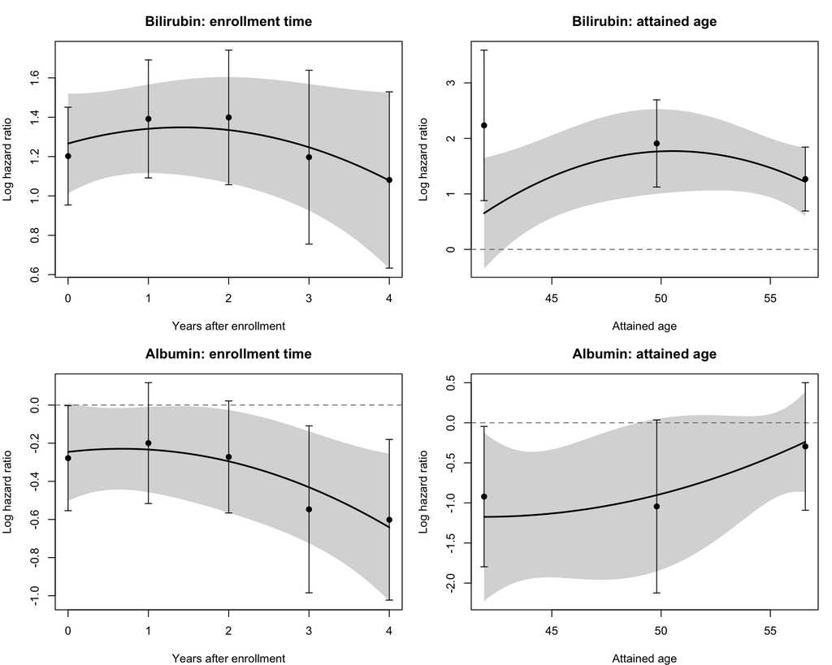

```r
plot_effect_comparison <- function(curve, disjoint_rows, title, x_label,
                                   y_label = "Log hazard ratio") {
  plot_range <- range(
    curve$lower, curve$upper,
    disjoint_rows$disjoint_lower, disjoint_rows$disjoint_upper,
    finite = TRUE
  )
  plot(
    curve$landmark, curve$estimate, type = "n",
    xlab = x_label, ylab = y_label, main = title, ylim = plot_range
  )
  polygon(
    c(curve$landmark, rev(curve$landmark)),
    c(curve$lower, rev(curve$upper)),
    border = NA, col = "grey85"
  )
  abline(h = 0, lty = 2, col = "grey45")
  lines(curve$landmark, curve$estimate, lwd = 2)
  finite <- is.finite(disjoint_rows$disjoint_estimate) &
    is.finite(disjoint_rows$disjoint_lower) &
    is.finite(disjoint_rows$disjoint_upper)
  arrows(
    disjoint_rows$landmark[finite], disjoint_rows$disjoint_lower[finite],
    disjoint_rows$landmark[finite], disjoint_rows$disjoint_upper[finite],
    angle = 90, code = 3, length = 0.04
  )
  points(
    disjoint_rows$landmark[finite],
    disjoint_rows$disjoint_estimate[finite], pch = 19
  )
}

enrollment_grid <- seq(
  min(enrollment_landmarks), max(enrollment_landmarks), length.out = 200L
)
age_grid <- seq(min(age_landmarks), max(age_landmarks), length.out = 200L)
dynamic_curves <- list(
  enrollment_bili = dynamic_log_hazard_ratio(
    enrollment_fit, "log_bili_z", enrollment_grid, enrollment_basis
  ),
  age_bili = dynamic_log_hazard_ratio(
    age_fit, "log_bili_z", age_grid, age_basis
  ),
  enrollment_albumin = dynamic_log_hazard_ratio(
    enrollment_fit, "albumin_z", enrollment_grid, enrollment_basis
  ),
  age_albumin = dynamic_log_hazard_ratio(
    age_fit, "albumin_z", age_grid, age_basis
  )
)

old_parameters <- par(mfrow = c(2, 2), mar = c(4, 4, 3, 1))
plot_effect_comparison(
  dynamic_curves$enrollment_bili,
  disjoint_comparison[
    disjoint_comparison$scale == "Enrollment time" &
      disjoint_comparison$covariate == "log_bili_z", ],
  "Bilirubin: enrollment time", "Years after enrollment"
)
plot_effect_comparison(
  dynamic_curves$age_bili,
  disjoint_comparison[
    disjoint_comparison$scale == "Attained age" &
      disjoint_comparison$covariate == "log_bili_z", ],
  "Bilirubin: attained age", "Attained age"
)
plot_effect_comparison(
  dynamic_curves$enrollment_albumin,
  disjoint_comparison[
    disjoint_comparison$scale == "Enrollment time" &
      disjoint_comparison$covariate == "albumin_z", ],
  "Albumin: enrollment time", "Years after enrollment"
)
plot_effect_comparison(
  dynamic_curves$age_albumin,
  disjoint_comparison[
    disjoint_comparison$scale == "Attained age" &
      disjoint_comparison$covariate == "albumin_z", ],
  "Albumin: attained age", "Attained age"
)
```

```r
par(old_parameters)
```

The fixed-effect panels make the pooling distinction explicit. The enrollment and age supermodels each use one effect for these covariates, while the disjoint estimates spend a separate coefficient at every landmark.

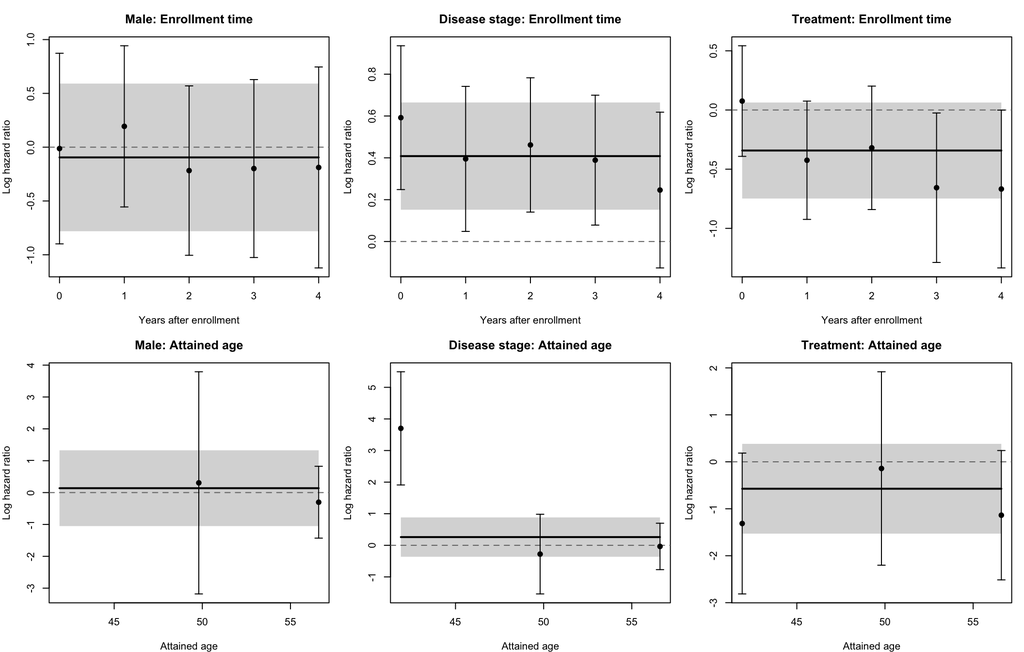

```r
constant_effect_curve <- function(supermodel, covariate, grid) {
  row <- extract_robust_inference(supermodel)
  row <- row[row$term == covariate, ]
  stopifnot(nrow(row) == 1L)
  data.frame(
    landmark = grid,
    estimate = row$estimate,
    lower = row$lower,
    upper = row$upper
  )
}

old_parameters <- par(mfrow = c(2, 3), mar = c(4, 4, 3, 1))
for (scale_label in c("Enrollment time", "Attained age")) {
  supermodel <- if (scale_label == "Enrollment time") enrollment_fit else age_fit
  grid <- if (scale_label == "Enrollment time") enrollment_grid else age_grid
  x_label <- if (scale_label == "Enrollment time") "Years after enrollment" else "Attained age"
  for (covariate in shared_fixed_covariates) {
    plot_effect_comparison(
      constant_effect_curve(supermodel, covariate, grid),
      disjoint_comparison[
        disjoint_comparison$scale == scale_label &
          disjoint_comparison$covariate == covariate, ],
      paste(unname(term_labels[covariate]), scale_label, sep = ": "),
      x_label
    )
  }
}
```

```r
par(old_parameters)
```

# 10 Predictive performance

I first computed apparent performance on the exact rows used for model fitting. I then estimated Harrell’s bootstrap optimism by resampling subjects, rebuilding every stack, refitting both supermodels and every disjoint model, and evaluating each bootstrap fit in both its resample and the original cohort. Duplicated subjects received new identifiers, so clustering never treated two bootstrap copies as the same person.

## 10.1 Apparent landmark-specific performance

```r
prediction_key <- function(data) {
  paste(data$id, sprintf("%.12g", data$LM), sep = "::")
}

align_prediction <- function(prediction, target_stack) {
  target_key <- prediction_key(target_stack$data)
  source_key <- prediction_key(prediction$data)
  stopifnot(!anyDuplicated(target_key), !anyDuplicated(source_key))
  index <- match(target_key, source_key)
  stopifnot(!anyNA(index))
  prediction$data <- prediction$data[index, , drop = FALSE]
  prediction$preds <- prediction$preds[index, , drop = FALSE]
  stopifnot(identical(prediction_key(prediction$data), target_key))
  prediction
}

subset_prediction <- function(prediction, landmark) {
  index <- prediction$data$LM == landmark
  out <- prediction
  out$data <- prediction$data[index, , drop = FALSE]
  out$preds <- prediction$preds[index, , drop = FALSE]
  stopifnot(nrow(out$data) == nrow(out$preds), nrow(out$data) > 0L)
  out
}

predict_disjoint_by_landmark <- function(disjoint_result, target_stack,
                                         landmarks) {
  setNames(lapply(landmarks, function(landmark) {
    record <- get_disjoint_record(disjoint_result, landmark)
    if (inherits(record$value, "error")) return(record$value)
    target <- subset_lmdata(target_stack, landmark)
    prediction_record <- capture_conditions(predict(
      record$value, newdata = target, cause = cause_of_interest
    ))
    prediction_record$value
  }), as.character(landmarks))
}

enrollment_prediction_record <- capture_conditions(predict(
  enrollment_fit, newdata = enrollment_stack, cause = cause_of_interest
))
age_prediction_record <- capture_conditions(predict(
  age_fit, newdata = age_stack, cause = cause_of_interest
))
enrollment_disjoint_prediction_records <- predict_disjoint_by_landmark(
  enrollment_disjoint, enrollment_stack_raw, enrollment_landmarks
)
age_disjoint_prediction_records <- predict_disjoint_by_landmark(
  age_disjoint, age_stack_raw, age_landmarks
)

prediction_records <- list(
  enrollment_prediction_record,
  age_prediction_record
)
stopifnot(
  !any(vapply(prediction_records, function(record) {
    inherits(record$value, "error")
  }, logical(1L))),
  all(vapply(prediction_records, function(record) {
    length(record$warnings) == 0L
  }, logical(1L)))
)

enrollment_predictions <- align_prediction(
  enrollment_prediction_record$value, enrollment_stack
)
age_predictions <- align_prediction(age_prediction_record$value, age_stack)

score_predictions_by_landmark <- function(super_prediction,
                                          disjoint_predictions,
                                          landmarks, scale_label) {
  rows <- list()
  failures <- list()
  for (landmark in landmarks) {
    super_one <- subset_prediction(super_prediction, landmark)
    model_list <- list(Supermodel = super_one)
    disjoint_one <- disjoint_predictions[[as.character(landmark)]]
    if (inherits(disjoint_one, "error")) {
      failures[[length(failures) + 1L]] <- data.frame(
        scale = scale_label, landmark = landmark, method = "Disjoint",
        stage = "prediction", error = conditionMessage(disjoint_one)
      )
    } else {
      stopifnot(identical(
        prediction_key(super_one$data), prediction_key(disjoint_one$data)
      ))
      disjoint_one$data <- super_one$data
      model_list$Disjoint <- disjoint_one
    }
    score_record <- capture_conditions(score(
      model_list, times = landmark, metrics = c("auc", "brier"),
      id_col = "id", cause = cause_of_interest,
      summary = FALSE, contrasts = FALSE
    ))
    if (inherits(score_record$value, "error")) {
      failures[[length(failures) + 1L]] <- data.frame(
        scale = scale_label, landmark = landmark, method = "All available",
        stage = "score", error = conditionMessage(score_record$value)
      )
      next
    }
    auc <- as.data.frame(score_record$value$AUC$score)
    brier <- as.data.frame(score_record$value$Brier$score)
    auc$model <- as.character(auc$model)
    brier$model <- as.character(brier$model)
    available <- names(model_list)
    auc <- auc[auc$model %in% available, c("model", "AUC")]
    brier <- brier[brier$model %in% available, c("model", "Brier")]
    metric <- merge(auc, brier, by = "model", sort = FALSE)
    rows[[length(rows) + 1L]] <- transform(
      metric, scale = scale_label, landmark = landmark
    )[c("scale", "landmark", "model", "AUC", "Brier")]
  }
  list(
    score = if (length(rows)) do.call(rbind, rows) else NULL,
    failures = if (length(failures)) do.call(rbind, failures) else data.frame()
  )
}

enrollment_apparent <- score_predictions_by_landmark(
  enrollment_predictions, enrollment_disjoint_prediction_records,
  enrollment_landmarks, "Enrollment time"
)
age_apparent <- score_predictions_by_landmark(
  age_predictions, age_disjoint_prediction_records,
  age_landmarks, "Attained age"
)
ordinary_apparent_scores <- rbind(
  enrollment_apparent$score, age_apparent$score
)
apparent_prediction_failures <- rbind(
  enrollment_apparent$failures, age_apparent$failures
)

age_landmark_score_record <- capture_conditions(score(
  list("Age scale" = age_predictions),
  times = age_landmarks, metrics = c("auc", "brier"),
  id_col = "id", cause = cause_of_interest,
  summary = FALSE, contrasts = FALSE
))
stopifnot(!inherits(age_landmark_score_record$value, "error"))
```

Before selecting a common scoring path, I checked `score_left_truncated()` against `score()` for both methods on both scales.

```r
score_lt_by_landmark <- function(super_prediction, disjoint_predictions,
                                 landmarks, scale_label, time_column) {
  rows <- list()
  for (landmark in landmarks) {
    predictions <- list(
      Supermodel = subset_prediction(super_prediction, landmark),
      Disjoint = disjoint_predictions[[as.character(landmark)]]
    )
    predictions <- predictions[!vapply(predictions, inherits, logical(1L), what = "error")]
    for (method in names(predictions)) {
      prediction <- predictions[[method]]
      record <- capture_conditions(score_left_truncated(
        risk = setNames(data.frame(prediction$preds$risk), method),
        data = prediction$data,
        time_col = time_column, status_col = "status", entry_col = "LM",
        landmark_col = "LM", id_col = "id", cause = cause_of_interest,
        w = prediction_window
      ))
      if (!inherits(record$value, "error")) {
        row <- record$value$score
        row$scale <- scale_label
        rows[[length(rows) + 1L]] <- row[c(
          "scale", "landmark", "model", "AUC", "Brier"
        )]
      }
    }
  }
  do.call(rbind, rows)
}

left_truncated_apparent_scores <- rbind(
  score_lt_by_landmark(
    enrollment_predictions, enrollment_disjoint_prediction_records,
    enrollment_landmarks, "Enrollment time", "time"
  ),
  score_lt_by_landmark(
    age_predictions, age_disjoint_prediction_records,
    age_landmarks, "Attained age", "exit_age"
  )
)

score_comparison <- merge(
  ordinary_apparent_scores,
  left_truncated_apparent_scores[c("scale", "landmark", "model", "AUC", "Brier")],
  by = c("scale", "landmark", "model"),
  suffixes = c("_score", "_score_left_truncated"),
  sort = FALSE
)
score_agreement <- do.call(rbind, lapply(
  split(score_comparison, list(score_comparison$scale, score_comparison$model), drop = TRUE),
  function(rows) {
    data.frame(
      scale = rows$scale[1L], model = rows$model[1L],
      maximum_AUC_difference = max(abs(
        rows$AUC_score - rows$AUC_score_left_truncated
      )),
      maximum_Brier_difference = max(abs(
        rows$Brier_score - rows$Brier_score_left_truncated
      )),
      row.names = NULL
    )
  }
))
rownames(score_agreement) <- NULL

agreement_tolerance <- 1e-12
stopifnot(all(
  score_agreement$maximum_AUC_difference[
    score_agreement$scale == "Attained age"
  ] < agreement_tolerance &
    score_agreement$maximum_Brier_difference[
      score_agreement$scale == "Attained age"
    ] < agreement_tolerance
))
all_paths_agree <- all(
  score_agreement$maximum_AUC_difference < agreement_tolerance &
    score_agreement$maximum_Brier_difference < agreement_tolerance
)
scoring_decision <- if (all_paths_agree) {
  "The two functions agreed on both scales, so I used score_left_truncated() for the comparison."
} else {
  paste(
    "The functions did not agree on both scales. I therefore used score()",
    "with summary = FALSE for every landmark, method, and bootstrap sample,",
    "which kept the estimator identical across the comparison."
  )
}

knitr::kable(score_agreement, digits = 16)
```

| scale | model | maximum_AUC_difference | maximum_Brier_difference |
| --- | --- | --- | --- |
| Attained age | Disjoint | 1.000000e-16 | 0.000000000 |
| Enrollment time | Disjoint | 2.051001e-02 | 0.009581184 |
| Attained age | Supermodel | 2.000000e-16 | 0.000000000 |
| Enrollment time | Supermodel | 1.761882e-02 | 0.008835724 |

```r
cat(scoring_decision)
```

```
## The functions did not agree on both scales. I therefore used score() with summary = FALSE for every landmark, method, and bootstrap sample, which kept the estimator identical across the comparison.
```

The apparent results below use `score()` on identical rows for the two approaches.

```r
apparent_grid <- rbind(
  expand.grid(
    scale = "Enrollment time", landmark = enrollment_landmarks,
    model = c("Supermodel", "Disjoint"), stringsAsFactors = FALSE
  ),
  expand.grid(
    scale = "Attained age", landmark = age_landmarks,
    model = c("Supermodel", "Disjoint"), stringsAsFactors = FALSE
  )
)
apparent_performance <- merge(
  apparent_grid, ordinary_apparent_scores,
  by = c("scale", "landmark", "model"), all.x = TRUE, sort = FALSE
)
apparent_performance$performance_flag <- ifelse(
  is.finite(apparent_performance$AUC) & is.finite(apparent_performance$Brier),
  "ok", "prediction or score unavailable"
)
names(apparent_performance)[names(apparent_performance) == "model"] <- "method"
knitr::kable(apparent_performance, digits = 4)
```

| scale | landmark | method | AUC | Brier | performance_flag |
| --- | --- | --- | --- | --- | --- |
| Enrollment time | 0.0 | Supermodel | 0.9129 | 0.1041 | ok |
| Enrollment time | 1.0 | Supermodel | 0.8937 | 0.1087 | ok |
| Enrollment time | 2.0 | Supermodel | 0.8688 | 0.1198 | ok |
| Enrollment time | 3.0 | Supermodel | 0.8490 | 0.1310 | ok |
| Enrollment time | 4.0 | Supermodel | 0.8312 | 0.1454 | ok |
| Enrollment time | 0.0 | Disjoint | 0.9162 | 0.1015 | ok |
| Enrollment time | 1.0 | Disjoint | 0.8942 | 0.1077 | ok |
| Enrollment time | 2.0 | Disjoint | 0.8688 | 0.1227 | ok |
| Enrollment time | 3.0 | Disjoint | 0.8488 | 0.1249 | ok |
| Enrollment time | 4.0 | Disjoint | 0.8319 | 0.1416 | ok |
| Attained age | 41.9 | Supermodel | 0.8001 | 0.1646 | ok |
| Attained age | 49.8 | Supermodel | 0.8980 | 0.1082 | ok |
| Attained age | 56.6 | Supermodel | 0.7324 | 0.1717 | ok |
| Attained age | 49.8 | Disjoint | 0.9168 | 0.1003 | ok |
| Attained age | 56.6 | Disjoint | 0.7253 | 0.1685 | ok |
| Attained age | 41.9 | Disjoint | NA | NA | prediction or score unavailable |

```r
if (nrow(apparent_prediction_failures)) {
  knitr::kable(apparent_prediction_failures)
}
```

| scale | landmark | method | stage | error |
| --- | --- | --- | --- | --- |
| Attained age | 41.9 | Disjoint | prediction | all rows of newdata have missing values |

## 10.2 Existing summary-metric behavior

The current summary implementation assumes that the first landmark contains every subject who appears later. That assumption holds after a shared enrollment origin but fails under staggered age entry. I retained the exact age-scale failure and the pending analytic variance statement.

```r
enrollment_score_record <- capture_conditions(score(
  list("Enrollment scale" = enrollment_predictions),
  times = enrollment_landmarks,
  metrics = c("auc", "brier"), id_col = "id", cause = cause_of_interest,
  summary = TRUE, contrasts = FALSE
))
age_summary_failure <- capture_conditions(score(
  list("Age scale" = age_predictions),
  times = age_landmarks,
  metrics = c("auc", "brier"), id_col = "id", cause = cause_of_interest,
  summary = TRUE, contrasts = FALSE
))
age_left_truncated_score_record <- capture_conditions(score_left_truncated(
  risk = setNames(data.frame(age_predictions$preds$risk), "Age scale"),
  data = age_predictions$data,
  time_col = "exit_age", status_col = "status", entry_col = "LM",
  landmark_col = "LM", id_col = "id", cause = cause_of_interest,
  w = prediction_window
))

score_condition_table <- data.frame(
  operation = c(
    "Enrollment score with summary", "Age score without summary",
    "Age score with summary", "Age left-truncated point summary"
  ),
  warning_count = c(
    length(enrollment_score_record$warnings),
    length(age_landmark_score_record$warnings),
    length(age_summary_failure$warnings),
    length(age_left_truncated_score_record$warnings)
  ),
  error = c(
    if (inherits(enrollment_score_record$value, "error")) conditionMessage(enrollment_score_record$value) else "",
    if (inherits(age_landmark_score_record$value, "error")) conditionMessage(age_landmark_score_record$value) else "",
    if (inherits(age_summary_failure$value, "error")) conditionMessage(age_summary_failure$value) else "",
    if (inherits(age_left_truncated_score_record$value, "error")) conditionMessage(age_left_truncated_score_record$value) else ""
  ),
  row.names = NULL
)
knitr::kable(score_condition_table)
```

| operation | warning_count | error |
| --- | --- | --- |
| Enrollment score with summary | 0 |  |
| Age score without summary | 0 |  |
| Age score with summary | 0 | Subsample size mismatch. |
| Age left-truncated point summary | 0 |  |

```r
stopifnot(
  !inherits(enrollment_score_record$value, "error"),
  inherits(age_summary_failure$value, "error"),
  identical(conditionMessage(age_summary_failure$value), "Subsample size mismatch."),
  !inherits(age_left_truncated_score_record$value, "error")
)

enrollment_scores <- enrollment_score_record$value
age_left_truncated_scores <- age_left_truncated_score_record$value
enrollment_auc_summary <- enrollment_scores$AUC_summary$score
enrollment_auc_summary <- enrollment_auc_summary[
  enrollment_auc_summary$model == "Enrollment scale",
]
enrollment_brier_summary <- enrollment_scores$Brier_summary$score
enrollment_brier_summary <- enrollment_brier_summary[
  enrollment_brier_summary$model == "Enrollment scale",
]
age_summary <- age_left_truncated_scores$summary

summary_performance <- data.frame(
  scale = c("Enrollment time", "Attained age"),
  summary_auc = c(enrollment_auc_summary$AUC, age_summary$AUC),
  summary_auc_standard_error = c(enrollment_auc_summary$se, NA_real_),
  summary_brier = c(enrollment_brier_summary$Brier, age_summary$Brier),
  summary_brier_standard_error = c(enrollment_brier_summary$se, NA_real_),
  inference = c(
    "Original analytic summary calculation",
    "Point summary only; paired difference intervals below are percentiles of subject-resampled corrected differences"
  ),
  row.names = NULL
)
knitr::kable(summary_performance, digits = 4)
```

| scale | summary_auc | summary_auc_standard_error | summary_brier | summary_brier_standard_error | inference |
| --- | --- | --- | --- | --- | --- |
| Enrollment time | 0.8711 | 0.0365 | 0.1218 | 0.0082 | Original analytic summary calculation |
| Attained age | 0.8102 | NA | 0.1482 | NA | Point summary only; paired difference intervals below are percentiles of subject-resampled corrected differences |

These summary values answer different prediction questions in different landmark populations. I treated them as descriptive rather than as evidence that one clock was better.

## 10.3 Harrell-bootstrap optimism correction

The bootstrap used 200 subject resamples and seed 20260922. The transformations, landmarks, and prediction window stayed fixed at their original values.

```r
build_analysis_stacks <- function(longitudinal_data) {
  enrollment_raw <- stack_data(
    data = longitudinal_data,
    outcome = list(time = "time", status = "status"),
    lms = enrollment_landmarks, w = prediction_window,
    covs = list(
      fixed = c(shared_fixed_covariates, "age_at_enrollment"),
      varying = updated_laboratory_covariates
    ),
    format = "long", id = "id", rtime = "tstart"
  )
  enrollment_raw$data$attained_age_z <- (
    enrollment_raw$data$age_at_enrollment + enrollment_raw$data$LM - age_center
  ) / age_scale

  age_long <- transform(
    longitudinal_data,
    entry_age = age_at_enrollment,
    exit_age = age_at_enrollment + time,
    visit_age = age_at_enrollment + tstart
  )
  age_raw <- stack_data(
    data = age_long,
    outcome = list(time = "exit_age", status = "status"),
    lms = age_landmarks, w = prediction_window,
    covs = list(
      fixed = shared_fixed_covariates,
      varying = updated_laboratory_covariates
    ),
    format = "long", id = "id", rtime = "visit_age",
    entry = "entry_age", entry_mode = "strict"
  )

  enrollment_model <- add_interactions(
    enrollment_raw,
    lm_covs = updated_laboratory_covariates,
    func_covars = enrollment_basis,
    func_lms = enrollment_basis
  )
  age_model <- add_interactions(
    age_raw,
    lm_covs = updated_laboratory_covariates,
    func_covars = age_basis,
    func_lms = list()
  )
  stopifnot(
    identical(
      prediction_key(enrollment_raw$data),
      prediction_key(enrollment_model$data)
    ),
    identical(prediction_key(age_raw$data), prediction_key(age_model$data)),
    anyDuplicated(enrollment_raw$data[c("id", "LM")]) == 0L,
    anyDuplicated(enrollment_model$data[c("id", "LM")]) == 0L,
    anyDuplicated(age_raw$data[c("id", "LM")]) == 0L,
    anyDuplicated(age_model$data[c("id", "LM")]) == 0L
  )
  list(
    enrollment_raw = enrollment_raw, enrollment_model = enrollment_model,
    age_raw = age_raw, age_model = age_model
  )
}

resample_subjects <- function(longitudinal_data, sampled_ids) {
  pieces <- lapply(seq_along(sampled_ids), function(index) {
    subject_rows <- longitudinal_data[
      longitudinal_data$id == sampled_ids[index], , drop = FALSE
    ]
    stopifnot(nrow(subject_rows) > 0L)
    subject_rows$.bootstrap_source_id <- subject_rows$id
    subject_rows$id <- index
    subject_rows
  })
  out <- do.call(rbind, pieces)
  rownames(out) <- NULL
  stopifnot(
    length(unique(out$id)) == length(sampled_ids),
    all(vapply(
      split(out$.bootstrap_source_id, out$id),
      function(source_ids) length(unique(source_ids)) == 1L,
      logical(1L)
    ))
  )
  out$.bootstrap_source_id <- NULL
  out
}

fit_bootstrap_disjoint <- function(lmdata, landmarks, formula) {
  setNames(lapply(landmarks, function(landmark) {
    capture_conditions(dynamic_lm(
      subset_lmdata(lmdata, landmark), formula,
      type = "CSC", method = "breslow", x = TRUE
    ))
  }), as.character(landmarks))
}

bind_non_null <- function(objects) {
  objects <- objects[!vapply(objects, is.null, logical(1L))]
  if (length(objects)) do.call(rbind, objects) else NULL
}

score_prediction_diagnostic <- function(prediction, landmark) {
  record <- capture_conditions(score(
    list(Model = prediction), times = landmark,
    metrics = c("auc", "brier"), id_col = "id",
    cause = cause_of_interest, summary = FALSE, contrasts = FALSE
  ))
  if (inherits(record$value, "error")) {
    return(list(ok = FALSE, error = conditionMessage(record$value)))
  }
  auc <- as.data.frame(record$value$AUC$score)
  brier <- as.data.frame(record$value$Brier$score)
  auc <- auc[as.character(auc$model) == "Model", , drop = FALSE]
  brier <- brier[as.character(brier$model) == "Model", , drop = FALSE]
  ok <- nrow(auc) == 1L && nrow(brier) == 1L &&
    is.finite(auc$AUC) && is.finite(brier$Brier)
  list(ok = ok, error = if (ok) "" else "non-finite or missing score")
}

direct_age_cause_fit <- function(lmdata, formula, cause) {
  rhs <- paste(deparse(formula[[3L]]), collapse = "")
  direct_formula <- as.formula(paste0(
    "Surv(LM, exit_age, status == ", cause, ") ~ ", rhs
  ))
  capture_conditions(survival::coxph(
    direct_formula, data = lmdata$data, method = "breslow", x = TRUE
  ))
}

diagnose_age_fit <- function(fit_record, training_stack, formula, landmarks,
                             replicate, method) {
  rows <- list()
  model_error <- if (inherits(fit_record$value, "error")) {
    conditionMessage(fit_record$value)
  } else ""

  for (landmark in landmarks) {
    one_landmark <- subset_lmdata(training_stack, landmark)
    for (cause in c(transplant_code, cause_of_interest)) {
      event_count <- sum(one_landmark$data$status == cause)
      cause_fit <- NULL
      coefficient_names <- character()
      if (!inherits(fit_record$value, "error")) {
        cause_fit <- extract_cause_fit(fit_record$value, cause)
        coefficient_names <- names(coef(cause_fit))[!is.finite(coef(cause_fit))]
      }
      needs_direct_check <- inherits(fit_record$value, "error") ||
        length(fit_record$warnings) > 0L || length(coefficient_names) > 0L
      direct_record <- if (needs_direct_check) {
        direct_age_cause_fit(training_stack, formula, cause)
      } else NULL
      cause_error <- if (!is.null(direct_record) &&
                         inherits(direct_record$value, "error")) {
        conditionMessage(direct_record$value)
      } else ""
      cause_warning <- if (!is.null(direct_record)) {
        paste(direct_record$warnings, collapse = " | ")
      } else ""
      if (!is.null(direct_record) && !inherits(direct_record$value, "error")) {
        direct_coefficients <- coef(direct_record$value)
        coefficient_names <- union(
          coefficient_names,
          names(direct_coefficients)[!is.finite(direct_coefficients)]
        )
      }
      cause_event_times <- training_stack$data$exit_age[
        training_stack$data$status == cause
      ]
      last_event_time <- if (length(cause_event_times)) {
        max(cause_event_times)
      } else NA_real_
      horizon <- landmark + prediction_window
      rows[[length(rows) + 1L]] <- data.frame(
        replicate = replicate,
        method = method,
        landmark = landmark,
        cause = cause,
        events = event_count,
        model_fit_error = model_error,
        cause_fit_error = cause_error,
        cause_fit_warning = cause_warning,
        nonfinite_coefficients = paste(coefficient_names, collapse = ", "),
        horizon = horizon,
        last_event_time = last_event_time,
        horizon_past_last_event = is.finite(last_event_time) &&
          horizon > last_event_time,
        row.names = NULL
      )
    }
  }
  do.call(rbind, rows)
}
```

```r
diagnose_age_predictions <- function(fit_record, training_stack, test_stack,
                                     landmarks, replicate, method) {
  rows <- list()
  model_error <- inherits(fit_record$value, "error")
  predictions <- list()
  for (sample_name in c("bootstrap_train", "original_test")) {
    target <- if (sample_name == "bootstrap_train") training_stack else test_stack
    predictions[[sample_name]] <- if (model_error) {
      list(value = fit_record$value, warnings = character(), messages = character())
    } else {
      capture_conditions(predict(
        fit_record$value, newdata = target, cause = cause_of_interest,
        complete = FALSE
      ))
    }
  }

  for (landmark in landmarks) {
    row <- data.frame(
      replicate = replicate,
      method = method,
      landmark = landmark,
      train_prediction_error = "",
      test_prediction_error = "",
      train_na_predictions = NA_integer_,
      test_na_predictions = NA_integer_,
      train_scoring_error = "",
      test_scoring_error = "",
      row.names = NULL
    )
    for (sample_name in names(predictions)) {
      prefix <- if (sample_name == "bootstrap_train") "train" else "test"
      prediction_record <- predictions[[sample_name]]
      if (inherits(prediction_record$value, "error")) {
        row[[paste0(prefix, "_prediction_error")]] <-
          conditionMessage(prediction_record$value)
        next
      }
      prediction <- subset_prediction(prediction_record$value, landmark)
      na_predictions <- sum(is.na(prediction$preds$risk))
      row[[paste0(prefix, "_na_predictions")]] <- na_predictions
      score_record <- if (na_predictions > 0L) {
        list(ok = FALSE, error = "NA predictions")
      } else {
        score_prediction_diagnostic(prediction, landmark)
      }
      row[[paste0(prefix, "_scoring_error")]] <- score_record$error
    }
    rows[[length(rows) + 1L]] <- row
  }
  do.call(rbind, rows)
}

diagnose_age_model <- function(fit_record, training_stack, test_stack, formula,
                               landmarks, replicate, method) {
  list(
    fit = diagnose_age_fit(
      fit_record, training_stack, formula, landmarks, replicate, method
    ),
    prediction = diagnose_age_predictions(
      fit_record, training_stack, test_stack, landmarks, replicate, method
    )
  )
}

score_one_prediction <- function(prediction, landmark) {
  record <- capture_conditions(score(
    list(Model = prediction), times = landmark,
    metrics = c("auc", "brier"), id_col = "id",
    cause = cause_of_interest, summary = FALSE, contrasts = FALSE
  ))
  if (inherits(record$value, "error")) return(NULL)
  auc <- as.data.frame(record$value$AUC$score)
  brier <- as.data.frame(record$value$Brier$score)
  auc$model <- as.character(auc$model)
  brier$model <- as.character(brier$model)
  auc <- auc[auc$model == "Model", ]
  brier <- brier[brier$model == "Model", ]
  if (nrow(auc) != 1L || nrow(brier) != 1L ||
      !is.finite(auc$AUC) || !is.finite(brier$Brier)) return(NULL)
  data.frame(AUC = auc$AUC, Brier = brier$Brier)
}

evaluate_supermodel_bootstrap <- function(fit_record, training_stack,
                                          test_stack, landmarks,
                                          replicate, scale_label) {
  if (inherits(fit_record$value, "error")) return(NULL)
  training_prediction <- capture_conditions(predict(
    fit_record$value, newdata = training_stack, cause = cause_of_interest
  ))
  test_prediction <- capture_conditions(predict(
    fit_record$value, newdata = test_stack, cause = cause_of_interest
  ))
  if (inherits(training_prediction$value, "error") ||
      inherits(test_prediction$value, "error")) return(NULL)

  rows <- list()
  for (landmark in landmarks) {
    for (sample_name in c("bootstrap_train", "original_test")) {
      prediction <- if (sample_name == "bootstrap_train") {
        training_prediction$value
      } else test_prediction$value
      metric <- score_one_prediction(
        subset_prediction(prediction, landmark), landmark
      )
      if (!is.null(metric)) {
        rows[[length(rows) + 1L]] <- data.frame(
          replicate = replicate, scale = scale_label,
          method = "Supermodel", landmark = landmark,
          sample = sample_name, AUC = metric$AUC, Brier = metric$Brier
        )
      }
    }
  }
  if (length(rows)) do.call(rbind, rows) else NULL
}

evaluate_disjoint_bootstrap <- function(fit_records, training_stack,
                                        test_stack, landmarks,
                                        replicate, scale_label) {
  rows <- list()
  for (landmark in landmarks) {
    record <- fit_records[[as.character(landmark)]]
    if (inherits(record$value, "error")) next
    training_prediction <- capture_conditions(predict(
      record$value, newdata = subset_lmdata(training_stack, landmark),
      cause = cause_of_interest
    ))
    test_prediction <- capture_conditions(predict(
      record$value, newdata = subset_lmdata(test_stack, landmark),
      cause = cause_of_interest
    ))
    predictions <- list(
      bootstrap_train = training_prediction,
      original_test = test_prediction
    )
    for (sample_name in names(predictions)) {
      prediction_record <- predictions[[sample_name]]
      if (inherits(prediction_record$value, "error")) next
      metric <- score_one_prediction(prediction_record$value, landmark)
      if (!is.null(metric)) {
        rows[[length(rows) + 1L]] <- data.frame(
          replicate = replicate, scale = scale_label,
          method = "Disjoint", landmark = landmark,
          sample = sample_name, AUC = metric$AUC, Brier = metric$Brier
        )
      }
    }
  }
  if (length(rows)) do.call(rbind, rows) else NULL
}

original_stacks <- list(
  enrollment_raw = enrollment_stack_raw,
  enrollment_model = enrollment_stack,
  age_raw = age_stack_raw,
  age_model = age_stack
)

set.seed(bootstrap_seed)
original_ids <- unique(pbc_analysis$id)
bootstrap_samples <- lapply(seq_len(n_boot), function(replicate) {
  sample(original_ids, length(original_ids), replace = TRUE)
})
```

```r
run_bootstrap_replicate <- function(replicate) {
  bootstrap_long_record <- capture_conditions(resample_subjects(
    pbc_analysis, bootstrap_samples[[replicate]]
  ))
  if (inherits(bootstrap_long_record$value, "error")) {
    return(list(
      scores = NULL,
      stack = data.frame(
        replicate = replicate,
        resample_error = conditionMessage(bootstrap_long_record$value),
        stack_build_error = "",
        age_raw_duplicate_id_lm = NA_integer_,
        age_model_duplicate_id_lm = NA_integer_
      ),
      fit = NULL, prediction = NULL, unexpected = NULL
    ))
  }
  stacks_record <- capture_conditions(build_analysis_stacks(
    bootstrap_long_record$value
  ))
  if (inherits(stacks_record$value, "error")) {
    return(list(
      scores = NULL,
      stack = data.frame(
        replicate = replicate,
        resample_error = "",
        stack_build_error = conditionMessage(stacks_record$value),
        age_raw_duplicate_id_lm = NA_integer_,
        age_model_duplicate_id_lm = NA_integer_
      ),
      fit = NULL, prediction = NULL, unexpected = NULL
    ))
  }
  stacks <- stacks_record$value
  stack_diagnostic <- data.frame(
    replicate = replicate,
    resample_error = "",
    stack_build_error = "",
    age_raw_duplicate_id_lm = anyDuplicated(
      stacks$age_raw$data[c("id", "LM")]
    ),
    age_model_duplicate_id_lm = anyDuplicated(
      stacks$age_model$data[c("id", "LM")]
    )
  )

  enrollment_super_fit <- capture_conditions(dynamic_lm(
    stacks$enrollment_model, enrollment_formula,
    type = "CSC", method = "breslow", x = TRUE
  ))
  age_super_fit <- capture_conditions(dynamic_lm(
    stacks$age_model, age_formula,
    type = "CSC", method = "breslow", x = TRUE
  ))
  enrollment_disjoint_fits <- fit_bootstrap_disjoint(
    stacks$enrollment_raw, enrollment_landmarks,
    enrollment_disjoint_formula
  )
  age_disjoint_fits <- fit_bootstrap_disjoint(
    stacks$age_raw, age_landmarks, age_disjoint_formula
  )

  score_rows <- list(
    evaluate_supermodel_bootstrap(
      enrollment_super_fit, stacks$enrollment_model,
      original_stacks$enrollment_model, enrollment_landmarks,
      replicate, "Enrollment time"
    ),
    evaluate_disjoint_bootstrap(
      enrollment_disjoint_fits, stacks$enrollment_raw,
      original_stacks$enrollment_raw, enrollment_landmarks,
      replicate, "Enrollment time"
    ),
    evaluate_supermodel_bootstrap(
      age_super_fit, stacks$age_model, original_stacks$age_model,
      age_landmarks, replicate, "Attained age"
    ),
    evaluate_disjoint_bootstrap(
      age_disjoint_fits, stacks$age_raw, original_stacks$age_raw,
      age_landmarks, replicate, "Attained age"
    )
  )
  super_diagnostic <- diagnose_age_model(
    age_super_fit, stacks$age_model, original_stacks$age_model,
    age_formula, age_landmarks, replicate, "Supermodel"
  )
  disjoint_diagnostics <- lapply(age_landmarks, function(landmark) {
    diagnose_age_model(
      age_disjoint_fits[[as.character(landmark)]],
      subset_lmdata(stacks$age_raw, landmark),
      subset_lmdata(original_stacks$age_raw, landmark),
      age_disjoint_formula, landmark, replicate, "Disjoint"
    )
  })

  list(
    scores = bind_non_null(score_rows),
    stack = stack_diagnostic,
    fit = bind_non_null(c(
      list(super_diagnostic$fit),
      lapply(disjoint_diagnostics, `[[`, "fit")
    )),
    prediction = bind_non_null(c(
      list(super_diagnostic$prediction),
      lapply(disjoint_diagnostics, `[[`, "prediction")
    )),
    unexpected = NULL
  )
}

bootstrap_cores <- getOption(
  "timescale.bootstrap.cores",
  if (.Platform$OS.type == "windows") 1L else min(4L, parallel::detectCores(logical = FALSE))
)
safe_bootstrap_replicate <- function(replicate) {
  tryCatch(
    run_bootstrap_replicate(replicate),
    error = function(error) list(
      scores = NULL, stack = NULL, fit = NULL, prediction = NULL,
      unexpected = data.frame(
        replicate = replicate,
        error = conditionMessage(error),
        row.names = NULL
      )
    )
  )
}
if (.Platform$OS.type == "windows" || bootstrap_cores <= 1L) {
  bootstrap_results <- lapply(seq_len(n_boot), safe_bootstrap_replicate)
} else {
  bootstrap_results <- parallel::mclapply(
    seq_len(n_boot), safe_bootstrap_replicate,
    mc.cores = bootstrap_cores, mc.preschedule = FALSE
  )
}
bootstrap_scores <- bind_non_null(lapply(bootstrap_results, `[[`, "scores"))
age_stack_diagnostics <- bind_non_null(lapply(bootstrap_results, `[[`, "stack"))
age_fit_diagnostics <- bind_non_null(lapply(bootstrap_results, `[[`, "fit"))
age_prediction_diagnostics <- bind_non_null(lapply(
  bootstrap_results, `[[`, "prediction"
))
unexpected_bootstrap_errors <- bind_non_null(lapply(
  bootstrap_results, `[[`, "unexpected"
))
stopifnot(!is.null(bootstrap_scores))
rownames(bootstrap_scores) <- NULL

bootstrap_train <- bootstrap_scores[
  bootstrap_scores$sample == "bootstrap_train",
  c("replicate", "scale", "method", "landmark", "AUC", "Brier")
]
bootstrap_test <- bootstrap_scores[
  bootstrap_scores$sample == "original_test",
  c("replicate", "scale", "method", "landmark", "AUC", "Brier")
]
paired_bootstrap <- merge(
  bootstrap_train, bootstrap_test,
  by = c("replicate", "scale", "method", "landmark"),
  suffixes = c("_train", "_test")
)

bootstrap_optimism <- do.call(rbind, lapply(
  split(paired_bootstrap, list(
    paired_bootstrap$scale, paired_bootstrap$method,
    paired_bootstrap$landmark
  ), drop = TRUE),
  function(rows) {
    auc_optimism <- rows$AUC_train - rows$AUC_test
    brier_optimism <- rows$Brier_train - rows$Brier_test
    data.frame(
      scale = rows$scale[1L], method = rows$method[1L],
      landmark = rows$landmark[1L],
      successful_replicates = length(unique(rows$replicate)),
      failed_replicates = n_boot - length(unique(rows$replicate)),
      mean_AUC_optimism = mean(auc_optimism),
      Monte_Carlo_SE_AUC_optimism = sd(auc_optimism) / sqrt(length(auc_optimism)),
      mean_Brier_optimism = mean(brier_optimism),
      Monte_Carlo_SE_Brier_optimism = sd(brier_optimism) / sqrt(length(brier_optimism)),
      row.names = NULL
    )
  }
))
rownames(bootstrap_optimism) <- NULL
```

```r
optimism_corrected_performance <- merge(
  apparent_performance, bootstrap_optimism,
  by = c("scale", "method", "landmark"), all.x = TRUE, sort = FALSE
)
optimism_corrected_performance$successful_replicates[
  is.na(optimism_corrected_performance$successful_replicates)
] <- 0L
optimism_corrected_performance$failed_replicates[
  is.na(optimism_corrected_performance$failed_replicates)
] <- n_boot
optimism_corrected_performance$optimism_corrected_AUC <- with(
  optimism_corrected_performance, AUC - mean_AUC_optimism
)
optimism_corrected_performance$optimism_corrected_Brier <- with(
  optimism_corrected_performance, Brier - mean_Brier_optimism
)

stopifnot(
  all(optimism_corrected_performance$successful_replicates >= 0L),
  all(optimism_corrected_performance$failed_replicates >= 0L),
  all(optimism_corrected_performance$failed_replicates <= n_boot),
  all(
    optimism_corrected_performance$successful_replicates +
      optimism_corrected_performance$failed_replicates == n_boot
  )
)

age_stack_summary <- data.frame(
  bootstrap_replicates = n_boot,
  resample_errors = sum(nzchar(age_stack_diagnostics$resample_error)),
  stack_build_errors = sum(nzchar(age_stack_diagnostics$stack_build_error)),
  maximum_age_raw_duplicate_id_lm = max(
    age_stack_diagnostics$age_raw_duplicate_id_lm, na.rm = TRUE
  ),
  maximum_age_model_duplicate_id_lm = max(
    age_stack_diagnostics$age_model_duplicate_id_lm, na.rm = TRUE
  ),
  unexpected_replicate_errors = if (is.null(unexpected_bootstrap_errors)) {
    0L
  } else nrow(unexpected_bootstrap_errors),
  row.names = NULL
)

age_score_pair_counts <- aggregate(
  replicate ~ method + landmark,
  paired_bootstrap[paired_bootstrap$scale == "Attained age", ],
  function(replicates) length(unique(replicates))
)
names(age_score_pair_counts)[names(age_score_pair_counts) == "replicate"] <-
  "complete_score_pairs"
age_score_pair_grid <- expand.grid(
  method = c("Supermodel", "Disjoint"),
  landmark = age_landmarks,
  stringsAsFactors = FALSE
)
age_score_pair_counts <- merge(
  age_score_pair_grid, age_score_pair_counts,
  by = c("method", "landmark"), all.x = TRUE, sort = FALSE
)
age_score_pair_counts$complete_score_pairs[
  is.na(age_score_pair_counts$complete_score_pairs)
] <- 0L
age_score_pair_counts$failed_score_pairs <-
  n_boot - age_score_pair_counts$complete_score_pairs

age_fit_failure_tally <- do.call(rbind, lapply(
  split(age_fit_diagnostics, list(
    age_fit_diagnostics$method,
    age_fit_diagnostics$landmark,
    age_fit_diagnostics$cause
  ), drop = TRUE),
  function(rows) {
    data.frame(
      method = rows$method[1L],
      landmark = rows$landmark[1L],
      cause = rows$cause[1L],
      zero_event_replicates = sum(rows$events == 0L),
      model_fit_error_replicates = sum(nzchar(rows$model_fit_error)),
      cause_fit_error_replicates = sum(nzchar(rows$cause_fit_error)),
      warning_replicates = sum(nzchar(rows$cause_fit_warning)),
      nonfinite_coefficient_replicates = sum(
        nzchar(rows$nonfinite_coefficients)
      ),
      horizon_past_last_event_replicates = sum(
        rows$horizon_past_last_event
      ),
      row.names = NULL
    )
  }
))
age_fit_failure_tally <- merge(
  age_fit_failure_tally, age_score_pair_counts,
  by = c("method", "landmark"), all.x = TRUE, sort = FALSE
)
rownames(age_fit_failure_tally) <- NULL

age_prediction_failure_tally <- do.call(rbind, lapply(
  split(age_prediction_diagnostics, list(
    age_prediction_diagnostics$method,
    age_prediction_diagnostics$landmark
  ), drop = TRUE),
  function(rows) {
    data.frame(
      method = rows$method[1L],
      landmark = rows$landmark[1L],
      train_prediction_error_replicates = sum(nzchar(
        rows$train_prediction_error
      )),
      test_prediction_error_replicates = sum(nzchar(
        rows$test_prediction_error
      )),
      train_NA_prediction_replicates = sum(
        rows$train_na_predictions > 0L, na.rm = TRUE
      ),
      test_NA_prediction_replicates = sum(
        rows$test_na_predictions > 0L, na.rm = TRUE
      ),
      train_scoring_error_replicates = sum(nzchar(
        rows$train_scoring_error
      )),
      test_scoring_error_replicates = sum(nzchar(
        rows$test_scoring_error
      )),
      row.names = NULL
    )
  }
))
age_prediction_failure_tally <- merge(
  age_prediction_failure_tally, age_score_pair_counts,
  by = c("method", "landmark"), all.x = TRUE, sort = FALSE
)
rownames(age_prediction_failure_tally) <- NULL

failure_reason_rows <- list()
normalize_failure_reason <- function(reason) {
  if (grepl("^arguments imply differing number of rows:", reason)) {
    return("zero-event model returned no coefficient rows")
  }
  if (grepl("infinite argument in coxph.wtest", reason, fixed = TRUE)) {
    return("Cox Wald calculation had an infinite argument")
  }
  if (grepl("Ran out of iterations", reason, fixed = TRUE)) {
    return("Cox fit did not converge")
  }
  if (grepl("beta may be infinite", reason, fixed = TRUE)) {
    return("one or more Cox coefficients may be infinite")
  }
  reason
}
append_failure_reason <- function(method, landmark, cause, stage, reason) {
  failure_reason_rows[[length(failure_reason_rows) + 1L]] <<- data.frame(
    method = method,
    landmark = landmark,
    cause = as.character(cause),
    stage = stage,
    reason = normalize_failure_reason(reason),
    stringsAsFactors = FALSE
  )
}
for (row_index in seq_len(nrow(age_fit_diagnostics))) {
  row <- age_fit_diagnostics[row_index, ]
  if (row$events == 0L) {
    append_failure_reason(
      row$method, row$landmark, row$cause,
      "event count", "zero events inside the prediction window"
    )
  }
  if (nzchar(row$model_fit_error)) {
    append_failure_reason(
      row$method, row$landmark, row$cause,
      "competing-risk fit", row$model_fit_error
    )
  }
  if (nzchar(row$cause_fit_error)) {
    append_failure_reason(
      row$method, row$landmark, row$cause,
      "cause-specific fit", row$cause_fit_error
    )
  }
  if (nzchar(row$cause_fit_warning)) {
    append_failure_reason(
      row$method, row$landmark, row$cause,
      "cause-specific fit", row$cause_fit_warning
    )
  }
  if (nzchar(row$nonfinite_coefficients)) {
    append_failure_reason(
      row$method, row$landmark, row$cause,
      "cause-specific fit",
      "one or more non-finite coefficients"
    )
  }
}
for (row_index in seq_len(nrow(age_prediction_diagnostics))) {
  row <- age_prediction_diagnostics[row_index, ]
  prediction_fields <- c(
    train_prediction_error = "train prediction",
    test_prediction_error = "test prediction",
    train_scoring_error = "train scoring",
    test_scoring_error = "test scoring"
  )
  for (field in names(prediction_fields)) {
    if (nzchar(row[[field]])) {
      append_failure_reason(
        row$method, row$landmark, "joint CIF",
        unname(prediction_fields[field]), row[[field]]
      )
    }
  }
  if (is.finite(row$train_na_predictions) && row$train_na_predictions > 0L) {
    append_failure_reason(
      row$method, row$landmark, "joint CIF",
      "train prediction", "one or more NA risks"
    )
  }
  if (is.finite(row$test_na_predictions) && row$test_na_predictions > 0L) {
    append_failure_reason(
      row$method, row$landmark, "joint CIF",
      "test prediction", "one or more NA risks"
    )
  }
}
age_failure_reason_tally <- aggregate(
  list(replicates = rep(1L, length(failure_reason_rows))),
  by = do.call(rbind, failure_reason_rows),
  FUN = sum
)
age_failure_reason_tally <- age_failure_reason_tally[
  order(
    age_failure_reason_tally$method,
    age_failure_reason_tally$landmark,
    age_failure_reason_tally$cause,
    age_failure_reason_tally$stage,
    age_failure_reason_tally$reason
  ),
]
rownames(age_failure_reason_tally) <- NULL
```

```r
super_transplant_zero_by_replicate <- aggregate(
  events ~ replicate,
  age_fit_diagnostics[
    age_fit_diagnostics$method == "Supermodel" &
      age_fit_diagnostics$cause == transplant_code,
  ],
  function(events) any(events == 0L)
)
names(super_transplant_zero_by_replicate)[2L] <-
  "zero_transplants_in_any_age_window"
age_super_pair_grid <- expand.grid(
  replicate = seq_len(n_boot),
  landmark = age_landmarks,
  stringsAsFactors = FALSE
)
age_super_complete_pairs <- paired_bootstrap[
  paired_bootstrap$scale == "Attained age" &
    paired_bootstrap$method == "Supermodel",
  c("replicate", "landmark")
]
age_super_complete_pairs$complete_score_pair <- TRUE
age_super_pair_grid <- merge(
  age_super_pair_grid, age_super_complete_pairs,
  by = c("replicate", "landmark"), all.x = TRUE, sort = FALSE
)
age_super_pair_grid$complete_score_pair[
  is.na(age_super_pair_grid$complete_score_pair)
] <- FALSE
age_super_pair_grid <- merge(
  age_super_pair_grid, super_transplant_zero_by_replicate,
  by = "replicate", all.x = TRUE, sort = FALSE
)
age_super_zero_event_link <- do.call(rbind, lapply(
  split(age_super_pair_grid, list(
    age_super_pair_grid$landmark,
    age_super_pair_grid$zero_transplants_in_any_age_window
  ), drop = TRUE),
  function(rows) {
    data.frame(
      landmark = rows$landmark[1L],
      zero_transplants_in_any_age_window =
        rows$zero_transplants_in_any_age_window[1L],
      replicates = nrow(rows),
      complete_score_pairs = sum(rows$complete_score_pair),
      failed_score_pairs = sum(!rows$complete_score_pair),
      row.names = NULL
    )
  }
))
rownames(age_super_zero_event_link) <- NULL

age_pair_status <- expand.grid(
  replicate = seq_len(n_boot),
  method = c("Supermodel", "Disjoint"),
  landmark = age_landmarks,
  stringsAsFactors = FALSE
)
complete_age_pairs <- paired_bootstrap[
  paired_bootstrap$scale == "Attained age",
  c("replicate", "method", "landmark")
]
complete_age_pairs$complete_score_pair <- TRUE
age_pair_status <- merge(
  age_pair_status, complete_age_pairs,
  by = c("replicate", "method", "landmark"), all.x = TRUE, sort = FALSE
)
age_pair_status$complete_score_pair[
  is.na(age_pair_status$complete_score_pair)
] <- FALSE
age_horizon_link <- merge(
  age_fit_diagnostics, age_pair_status,
  by = c("replicate", "method", "landmark"), all.x = TRUE, sort = FALSE
)
age_horizon_summary <- do.call(rbind, lapply(
  split(age_horizon_link, list(
    age_horizon_link$method,
    age_horizon_link$landmark,
    age_horizon_link$cause
  ), drop = TRUE),
  function(rows) {
    data.frame(
      method = rows$method[1L],
      landmark = rows$landmark[1L],
      cause = rows$cause[1L],
      horizon_past_last_event_replicates = sum(
        rows$horizon_past_last_event
      ),
      complete_pairs_despite_past_horizon = sum(
        rows$horizon_past_last_event & rows$complete_score_pair
      ),
      row.names = NULL
    )
  }
))
rownames(age_horizon_summary) <- NULL

enrollment_super_replicates_retained <- length(unique(
  paired_bootstrap$replicate[
    paired_bootstrap$scale == "Enrollment time" &
      paired_bootstrap$method == "Supermodel" &
      paired_bootstrap$landmark == enrollment_landmarks[1L]
  ]
))

age_performance_pair_counts <- optimism_corrected_performance[
  optimism_corrected_performance$scale == "Attained age",
  c("method", "landmark", "successful_replicates")
]
age_pair_count_validation <- merge(
  age_score_pair_counts, age_performance_pair_counts,
  by = c("method", "landmark"), all = TRUE, sort = FALSE
)

stopifnot(
  nrow(age_stack_diagnostics) == n_boot,
  age_stack_summary$maximum_age_raw_duplicate_id_lm == 0L,
  age_stack_summary$maximum_age_model_duplicate_id_lm == 0L,
  nrow(age_pair_count_validation) == nrow(age_score_pair_counts),
  all(age_pair_count_validation$complete_score_pairs ==
        age_pair_count_validation$successful_replicates),
  enrollment_super_replicates_retained == n_boot
)
```

```r
knitr::kable(
  optimism_corrected_performance[c(
    "scale", "landmark", "method", "AUC", "mean_AUC_optimism",
    "optimism_corrected_AUC", "Brier", "mean_Brier_optimism",
    "optimism_corrected_Brier", "successful_replicates",
    "failed_replicates"
  )],
  digits = 4
)
```

| scale | landmark | method | AUC | mean_AUC_optimism | optimism_corrected_AUC | Brier | mean_Brier_optimism | optimism_corrected_Brier | successful_replicates | failed_replicates |
| --- | --- | --- | --- | --- | --- | --- | --- | --- | --- | --- |
| Enrollment time | 0.0 | Supermodel | 0.9129 | 0.0094 | 0.9036 | 0.1041 | -0.0051 | 0.1092 | 200 | 0 |
| Enrollment time | 1.0 | Supermodel | 0.8937 | 0.0102 | 0.8835 | 0.1087 | -0.0062 | 0.1148 | 200 | 0 |
| Enrollment time | 2.0 | Supermodel | 0.8688 | 0.0108 | 0.8580 | 0.1198 | -0.0077 | 0.1274 | 200 | 0 |
| Enrollment time | 3.0 | Supermodel | 0.8490 | 0.0159 | 0.8331 | 0.1310 | -0.0099 | 0.1409 | 200 | 0 |
| Enrollment time | 4.0 | Supermodel | 0.8312 | 0.0178 | 0.8134 | 0.1454 | -0.0117 | 0.1571 | 200 | 0 |
| Enrollment time | 0.0 | Disjoint | 0.9162 | 0.0106 | 0.9056 | 0.1015 | -0.0058 | 0.1073 | 200 | 0 |
| Enrollment time | 1.0 | Disjoint | 0.8942 | 0.0129 | 0.8813 | 0.1077 | -0.0079 | 0.1156 | 200 | 0 |
| Enrollment time | 2.0 | Disjoint | 0.8688 | 0.0135 | 0.8553 | 0.1227 | -0.0088 | 0.1315 | 200 | 0 |
| Enrollment time | 3.0 | Disjoint | 0.8488 | 0.0225 | 0.8263 | 0.1249 | -0.0138 | 0.1387 | 198 | 2 |
| Enrollment time | 4.0 | Disjoint | 0.8319 | 0.0292 | 0.8028 | 0.1416 | -0.0181 | 0.1597 | 186 | 14 |
| Attained age | 41.9 | Supermodel | 0.8001 | 0.0556 | 0.7444 | 0.1646 | -0.0278 | 0.1924 | 63 | 137 |
| Attained age | 49.8 | Supermodel | 0.8980 | 0.0521 | 0.8460 | 0.1082 | -0.0348 | 0.1429 | 60 | 140 |
| Attained age | 56.6 | Supermodel | 0.7324 | 0.0548 | 0.6776 | 0.1717 | -0.0272 | 0.1989 | 60 | 140 |
| Attained age | 49.8 | Disjoint | 0.9168 | 0.0578 | 0.8590 | 0.1003 | -0.0307 | 0.1310 | 140 | 60 |
| Attained age | 56.6 | Disjoint | 0.7253 | 0.0736 | 0.6518 | 0.1685 | -0.0328 | 0.2013 | 123 | 77 |
| Attained age | 41.9 | Disjoint | NA | NA | NA | NA | NA | NA | 0 | 200 |

The failure table counts a replicate as successful only when both the bootstrap-resample and original-cohort scores were available for that model and landmark. This makes sparse disjoint-model failures visible in the denominator.

```r
bootstrap_failure_table <- optimism_corrected_performance[c(
  "scale", "landmark", "method", "successful_replicates", "failed_replicates"
)]
knitr::kable(bootstrap_failure_table)
```

| scale | landmark | method | successful_replicates | failed_replicates |
| --- | --- | --- | --- | --- |
| Enrollment time | 0.0 | Supermodel | 200 | 0 |
| Enrollment time | 1.0 | Supermodel | 200 | 0 |
| Enrollment time | 2.0 | Supermodel | 200 | 0 |
| Enrollment time | 3.0 | Supermodel | 200 | 0 |
| Enrollment time | 4.0 | Supermodel | 200 | 0 |
| Enrollment time | 0.0 | Disjoint | 200 | 0 |
| Enrollment time | 1.0 | Disjoint | 200 | 0 |
| Enrollment time | 2.0 | Disjoint | 200 | 0 |
| Enrollment time | 3.0 | Disjoint | 198 | 2 |
| Enrollment time | 4.0 | Disjoint | 186 | 14 |
| Attained age | 41.9 | Supermodel | 63 | 137 |
| Attained age | 49.8 | Supermodel | 60 | 140 |
| Attained age | 56.6 | Supermodel | 60 | 140 |
| Attained age | 49.8 | Disjoint | 140 | 60 |
| Attained age | 56.6 | Disjoint | 123 | 77 |
| Attained age | 41.9 | Disjoint | 0 | 200 |

### 10.3.1 Age-scale bootstrap failure diagnosis

I first instrumented 50 resamples while diagnosing the failure path, then retained the same instrumentation for the complete 200-resample run reported here. The fit table is cause-specific. The prediction table is model-specific because a death cumulative-incidence prediction uses both the death and transplant cause-specific fits.

```r
zero_transplant_super_replicates <- sum(
  super_transplant_zero_by_replicate$zero_transplants_in_any_age_window
)
zero_transplant_pairs <- age_super_zero_event_link[
  age_super_zero_event_link$zero_transplants_in_any_age_window,
]
zero_transplant_pairs_all_failed <- all(
  zero_transplant_pairs$complete_score_pairs == 0L
)
zero_transplant_resample_word <- if (
  zero_transplant_super_replicates == 1L
) "resample" else "resamples"
whole_replicates_discarded <- n_boot - enrollment_super_replicates_retained
horizon_flag_has_successes <- any(
  age_horizon_summary$complete_pairs_despite_past_horizon > 0L
)
horizon_success_phrase <- if (horizon_flag_has_successes) {
  "did occur"
} else "did not occur"
age_failure_classification <- if (
  zero_transplant_super_replicates > 0L &&
    zero_transplant_pairs_all_failed &&
    whole_replicates_discarded == 0L
) {
  "genuine sparse competing-event fits, not an ID or whole-replicate control-flow bug"
} else {
  "not resolved by the recorded diagnostics"
}

knitr::kable(age_stack_summary)
```

| bootstrap_replicates | resample_errors | stack_build_errors | maximum_age_raw_duplicate_id_lm | maximum_age_model_duplicate_id_lm | unexpected_replicate_errors |
| --- | --- | --- | --- | --- | --- |
| 200 | 0 | 0 | 0 | 0 | 0 |

```r
knitr::kable(age_fit_failure_tally)
```

| method | landmark | cause | zero_event_replicates | model_fit_error_replicates | cause_fit_error_replicates | warning_replicates | nonfinite_coefficient_replicates | horizon_past_last_event_replicates | complete_score_pairs | failed_score_pairs |
| --- | --- | --- | --- | --- | --- | --- | --- | --- | --- | --- |
| Disjoint | 41.9 | 1 | 0 | 6 | 1 | 20 | 199 | 200 | 0 | 200 |
| Disjoint | 41.9 | 2 | 2 | 6 | 3 | 112 | 197 | 198 | 0 | 200 |
| Supermodel | 41.9 | 1 | 0 | 10 | 10 | 132 | 93 | 8 | 63 | 137 |
| Supermodel | 41.9 | 2 | 2 | 10 | 0 | 34 | 2 | 0 | 63 | 137 |
| Disjoint | 49.8 | 2 | 0 | 34 | 4 | 90 | 0 | 200 | 140 | 60 |
| Disjoint | 49.8 | 1 | 30 | 34 | 0 | 170 | 30 | 170 | 140 | 60 |
| Supermodel | 49.8 | 2 | 0 | 10 | 0 | 34 | 2 | 0 | 60 | 140 |
| Supermodel | 49.8 | 1 | 30 | 10 | 10 | 132 | 93 | 74 | 60 | 140 |
| Disjoint | 56.6 | 1 | 74 | 74 | 0 | 126 | 74 | 126 | 123 | 77 |
| Disjoint | 56.6 | 2 | 0 | 74 | 0 | 28 | 0 | 200 | 123 | 77 |
| Supermodel | 56.6 | 1 | 74 | 10 | 10 | 132 | 93 | 200 | 60 | 140 |
| Supermodel | 56.6 | 2 | 0 | 10 | 0 | 34 | 2 | 200 | 60 | 140 |

```r
knitr::kable(age_prediction_failure_tally)
```

| method | landmark | train_prediction_error_replicates | test_prediction_error_replicates | train_NA_prediction_replicates | test_NA_prediction_replicates | train_scoring_error_replicates | test_scoring_error_replicates | complete_score_pairs | failed_score_pairs |
| --- | --- | --- | --- | --- | --- | --- | --- | --- | --- |
| Disjoint | 41.9 | 200 | 200 | 0 | 0 | 0 | 0 | 0 | 200 |
| Supermodel | 41.9 | 127 | 128 | 9 | 9 | 9 | 9 | 63 | 137 |
| Disjoint | 49.8 | 34 | 37 | 23 | 23 | 23 | 23 | 140 | 60 |
| Supermodel | 49.8 | 127 | 128 | 12 | 12 | 12 | 12 | 60 | 140 |
| Disjoint | 56.6 | 74 | 74 | 3 | 3 | 3 | 3 | 123 | 77 |
| Supermodel | 56.6 | 127 | 128 | 12 | 12 | 12 | 12 | 60 | 140 |

```r
knitr::kable(age_failure_reason_tally)
```

| method | landmark | cause | stage | reason | replicates |
| --- | --- | --- | --- | --- | --- |
| Disjoint | 41.9 | 1 | cause-specific fit | Cox fit did not converge | 12 |
| Disjoint | 41.9 | 1 | cause-specific fit | Cox Wald calculation had an infinite argument | 1 |
| Disjoint | 41.9 | 1 | cause-specific fit | one or more Cox coefficients may be infinite | 8 |
| Disjoint | 41.9 | 1 | cause-specific fit | one or more non-finite coefficients | 199 |
| Disjoint | 41.9 | 1 | competing-risk fit | Cox Wald calculation had an infinite argument | 4 |
| Disjoint | 41.9 | 1 | competing-risk fit | zero-event model returned no coefficient rows | 2 |
| Disjoint | 41.9 | 2 | cause-specific fit | Cox fit did not converge | 111 |
| Disjoint | 41.9 | 2 | cause-specific fit | Cox Wald calculation had an infinite argument | 3 |
| Disjoint | 41.9 | 2 | cause-specific fit | one or more Cox coefficients may be infinite | 1 |
| Disjoint | 41.9 | 2 | cause-specific fit | one or more non-finite coefficients | 197 |
| Disjoint | 41.9 | 2 | competing-risk fit | Cox Wald calculation had an infinite argument | 4 |
| Disjoint | 41.9 | 2 | competing-risk fit | zero-event model returned no coefficient rows | 2 |
| Disjoint | 41.9 | 2 | event count | zero events inside the prediction window | 2 |
| Disjoint | 41.9 | joint CIF | test prediction | all rows of newdata have missing values | 194 |
| Disjoint | 41.9 | joint CIF | test prediction | Cox Wald calculation had an infinite argument | 4 |
| Disjoint | 41.9 | joint CIF | test prediction | zero-event model returned no coefficient rows | 2 |
| Disjoint | 41.9 | joint CIF | train prediction | all rows of newdata have missing values | 194 |
| Disjoint | 41.9 | joint CIF | train prediction | Cox Wald calculation had an infinite argument | 4 |
| Disjoint | 41.9 | joint CIF | train prediction | zero-event model returned no coefficient rows | 2 |
| Disjoint | 49.8 | 1 | cause-specific fit | Cox fit did not converge | 137 |
| Disjoint | 49.8 | 1 | cause-specific fit | one or more Cox coefficients may be infinite | 33 |
| Disjoint | 49.8 | 1 | cause-specific fit | one or more non-finite coefficients | 30 |
| Disjoint | 49.8 | 1 | competing-risk fit | Cox Wald calculation had an infinite argument | 4 |
| Disjoint | 49.8 | 1 | competing-risk fit | zero-event model returned no coefficient rows | 30 |
| Disjoint | 49.8 | 1 | event count | zero events inside the prediction window | 30 |
| Disjoint | 49.8 | 2 | cause-specific fit | Cox fit did not converge | 50 |
| Disjoint | 49.8 | 2 | cause-specific fit | Cox Wald calculation had an infinite argument | 4 |
| Disjoint | 49.8 | 2 | cause-specific fit | one or more Cox coefficients may be infinite | 40 |
| Disjoint | 49.8 | 2 | competing-risk fit | Cox Wald calculation had an infinite argument | 4 |
| Disjoint | 49.8 | 2 | competing-risk fit | zero-event model returned no coefficient rows | 30 |

[output cut: 83 more lines]

```r
knitr::kable(age_super_zero_event_link)
```

| landmark | zero_transplants_in_any_age_window | replicates | complete_score_pairs | failed_score_pairs |
| --- | --- | --- | --- | --- |
| 41.9 | FALSE | 104 | 63 | 41 |
| 49.8 | FALSE | 104 | 60 | 44 |
| 56.6 | FALSE | 104 | 60 | 44 |
| 41.9 | TRUE | 96 | 0 | 96 |
| 49.8 | TRUE | 96 | 0 | 96 |
| 56.6 | TRUE | 96 | 0 | 96 |

```r
knitr::kable(age_horizon_summary)
```

| method | landmark | cause | horizon_past_last_event_replicates | complete_pairs_despite_past_horizon |
| --- | --- | --- | --- | --- |
| Disjoint | 41.9 | 1 | 200 | 0 |
| Supermodel | 41.9 | 1 | 8 | 0 |
| Disjoint | 49.8 | 1 | 170 | 140 |
| Supermodel | 49.8 | 1 | 74 | 0 |
| Disjoint | 56.6 | 1 | 126 | 123 |
| Supermodel | 56.6 | 1 | 200 | 60 |
| Disjoint | 41.9 | 2 | 198 | 0 |
| Supermodel | 41.9 | 2 | 0 | 0 |
| Disjoint | 49.8 | 2 | 200 | 140 |
| Supermodel | 49.8 | 2 | 0 | 0 |
| Disjoint | 56.6 | 2 | 200 | 123 |
| Supermodel | 56.6 | 2 | 200 | 60 |

All resampled subject copies had distinct analysis identifiers, and the maximum duplicate count for `(id, LM)` was 0. There were 0 stack-build errors and 0 unexpected replicate errors. The enrollment supermodel retained complete pairs from all 200 resamples, so the safety wrapper discarded 0 whole replicates when an age component failed.

The dominant mechanism was sparse transplantation. In 96 resamples, at least one age window had no transplants. Every such resample lacked a complete age-supermodel score pair at every age landmark. The cause-specific table shows the associated convergence warnings and non-finite transplant-model coefficients. Because the age supermodel uses one competing-risk fit across all landmarks, an undefined transplant linear predictor prevents the death cumulative-incidence prediction at every landmark; this is why the supermodel success counts were nearly uniform. Scoring remained landmark-specific and did not discard the other age landmarks when only a score calculation failed.

The horizon check did not explain the failures. Complete score pairs did occur in rows whose horizon passed the last observed event, consistent with the step-function baseline hazard carrying forward after that event. I therefore classified the failure as genuine sparse competing-event fits, not an ID or whole-replicate control-flow bug.

I did not alter the age model or replace failed replicates. The optimism-corrected age values are conditional on the subset of resamples with finite competing-risk fits and complete train/test scores, so I would not use them as primary performance estimates. A future analysis could evaluate a denser age grid, a simpler transplant model, or a prespecified penalized competing-risk fit, but each would change the model and requires its own validation.

On the current attained-age grid, each landmark already has its own baseline because the windows do not overlap. With 3 landmarks and a quadratic laboratory basis containing 3 coefficients per laboratory, the laboratory effects are also effectively saturated across those landmarks. The primary attained-age supermodel therefore pools only male sex, disease stage, and treatment across landmarks; it cannot show the smoothing advantage that would require a denser, overlapping grid.

## 10.4 Paired supermodel-minus-disjoint performance differences

I paired the two methods within bootstrap replicate and landmark, retaining a replicate only when both methods had complete bootstrap-resample and original-cohort scores. A positive AUC difference or a negative Brier difference favors the supermodel. The percentile interval is the 2.5th and 97.5th percentiles of the replicate-specific optimism-corrected difference on that common set of paired resamples.

```r
paired_supermodel_scores <- paired_bootstrap[
  paired_bootstrap$method == "Supermodel",
  c(
    "replicate", "scale", "landmark",
    "AUC_train", "AUC_test", "Brier_train", "Brier_test"
  )
]
paired_disjoint_scores <- paired_bootstrap[
  paired_bootstrap$method == "Disjoint",
  c(
    "replicate", "scale", "landmark",
    "AUC_train", "AUC_test", "Brier_train", "Brier_test"
  )
]
paired_method_scores <- merge(
  paired_supermodel_scores,
  paired_disjoint_scores,
  by = c("replicate", "scale", "landmark"),
  suffixes = c("_supermodel", "_disjoint"),
  sort = FALSE
)

stopifnot(!anyDuplicated(
  paired_method_scores[c("replicate", "scale", "landmark")]
))

apparent_supermodel <- apparent_performance[
  apparent_performance$method == "Supermodel",
  c("scale", "landmark", "AUC", "Brier")
]
apparent_disjoint <- apparent_performance[
  apparent_performance$method == "Disjoint",
  c("scale", "landmark", "AUC", "Brier")
]
apparent_method_difference <- merge(
  apparent_supermodel,
  apparent_disjoint,
  by = c("scale", "landmark"),
  suffixes = c("_supermodel", "_disjoint"),
  all = TRUE,
  sort = FALSE
)
apparent_method_difference$apparent_AUC_difference <- with(
  apparent_method_difference, AUC_supermodel - AUC_disjoint
)
apparent_method_difference$apparent_Brier_difference <- with(
  apparent_method_difference, Brier_supermodel - Brier_disjoint
)

performance_difference_grid <- rbind(
  data.frame(
    scale = "Enrollment time",
    landmark = enrollment_landmarks,
    stringsAsFactors = FALSE
  ),
  data.frame(
    scale = "Attained age",
    landmark = age_landmarks,
    stringsAsFactors = FALSE
  )
)
performance_difference_grid <- merge(
  performance_difference_grid,
  apparent_method_difference[c(
    "scale", "landmark", "apparent_AUC_difference",
    "apparent_Brier_difference"
  )],
  by = c("scale", "landmark"),
  all.x = TRUE,
  sort = FALSE
)

paired_difference_rows <- lapply(
  split(
    paired_method_scores,
    list(paired_method_scores$scale, paired_method_scores$landmark),
    drop = TRUE
  ),
  function(rows) {
    apparent_row <- performance_difference_grid[
      performance_difference_grid$scale == rows$scale[1L] &
        performance_difference_grid$landmark == rows$landmark[1L],
    ]
    stopifnot(nrow(apparent_row) == 1L)

    auc_optimism_difference <- with(
      rows,
      (AUC_train_supermodel - AUC_test_supermodel) -
        (AUC_train_disjoint - AUC_test_disjoint)
    )
    brier_optimism_difference <- with(
      rows,
      (Brier_train_supermodel - Brier_test_supermodel) -
        (Brier_train_disjoint - Brier_test_disjoint)
    )
    corrected_auc_by_replicate <-
      apparent_row$apparent_AUC_difference - auc_optimism_difference
    corrected_brier_by_replicate <-
      apparent_row$apparent_Brier_difference - brier_optimism_difference

    data.frame(
      scale = rows$scale[1L],
      landmark = rows$landmark[1L],
      paired_replicates = length(unique(rows$replicate)),
      optimism_corrected_AUC_difference = mean(corrected_auc_by_replicate),
      AUC_difference_lower = unname(quantile(
        corrected_auc_by_replicate, 0.025, names = FALSE
      )),
      AUC_difference_upper = unname(quantile(
        corrected_auc_by_replicate, 0.975, names = FALSE
      )),
      optimism_corrected_Brier_difference = mean(corrected_brier_by_replicate),
      Brier_difference_lower = unname(quantile(
        corrected_brier_by_replicate, 0.025, names = FALSE
      )),
      Brier_difference_upper = unname(quantile(
        corrected_brier_by_replicate, 0.975, names = FALSE
      )),
      row.names = NULL
    )
  }
)
paired_performance_differences <- if (length(paired_difference_rows)) {
  do.call(rbind, paired_difference_rows)
} else {
  data.frame()
}

performance_differences <- merge(
  performance_difference_grid,
  paired_performance_differences,
  by = c("scale", "landmark"),
  all.x = TRUE,
  sort = FALSE
)
performance_differences$paired_replicates[
  is.na(performance_differences$paired_replicates)
] <- 0L
performance_differences <- performance_differences[order(
  match(performance_differences$scale, c("Enrollment time", "Attained age")),
  performance_differences$landmark
), ]
rownames(performance_differences) <- NULL
performance_differences$scale_display <- ifelse(
  performance_differences$scale == "Attained age",
  "Attained age (conditional on finite fits)",
  performance_differences$scale
)

format_difference_interval <- function(estimate, lower, upper) {
  ifelse(
    is.finite(estimate) & is.finite(lower) & is.finite(upper),
    sprintf("%.4f (%.4f, %.4f)", estimate, lower, upper),
    "—"
  )
}
performance_difference_display <- data.frame(
  scale = performance_differences$scale_display,
  landmark = performance_differences$landmark,
  apparent_AUC_difference = ifelse(
    is.finite(performance_differences$apparent_AUC_difference),
    sprintf("%.4f", performance_differences$apparent_AUC_difference),
    "—"
  ),
  corrected_AUC_difference_95_percentile_interval =
    format_difference_interval(
      performance_differences$optimism_corrected_AUC_difference,
      performance_differences$AUC_difference_lower,
      performance_differences$AUC_difference_upper
    ),
  apparent_Brier_difference = ifelse(
    is.finite(performance_differences$apparent_Brier_difference),
    sprintf("%.4f", performance_differences$apparent_Brier_difference),
    "—"
  ),
  corrected_Brier_difference_95_percentile_interval =
    format_difference_interval(
      performance_differences$optimism_corrected_Brier_difference,
      performance_differences$Brier_difference_lower,
      performance_differences$Brier_difference_upper
    ),
  paired_replicates = performance_differences$paired_replicates,
  row.names = NULL
)

stopifnot(
  nrow(performance_differences) ==
    length(enrollment_landmarks) + length(age_landmarks),
  all(performance_differences$paired_replicates >= 0L),
  all(performance_differences$paired_replicates <= n_boot),
  all(grepl(
    "conditional on finite fits",
    performance_difference_display$scale[
      performance_differences$scale == "Attained age"
    ],
    fixed = TRUE
  ))
)

finite_difference_rows <- performance_differences[
  is.finite(performance_differences$optimism_corrected_AUC_difference) &
    is.finite(performance_differences$optimism_corrected_Brier_difference),
]
auc_point_favors_supermodel <- sum(
  finite_difference_rows$optimism_corrected_AUC_difference > 0
)
brier_point_favors_supermodel <- sum(
  finite_difference_rows$optimism_corrected_Brier_difference < 0
)
auc_intervals_excluding_zero <- sum(
  finite_difference_rows$AUC_difference_lower > 0 |
    finite_difference_rows$AUC_difference_upper < 0
)
brier_intervals_excluding_zero <- sum(
  finite_difference_rows$Brier_difference_lower > 0 |
    finite_difference_rows$Brier_difference_upper < 0
)

knitr::kable(
  performance_difference_display,
  align = c("l", "r", "c", "c", "c", "c", "r"),
  caption = paste(
    "Supermodel minus disjoint performance differences.",
    "Positive AUC differences and negative Brier differences favor the supermodel."
  )
)
```

Supermodel minus disjoint performance differences. Positive AUC differences and negative Brier differences favor the supermodel.

| scale | landmark | apparent_AUC_difference | corrected_AUC_difference_95_percentile_interval | apparent_Brier_difference | corrected_Brier_difference_95_percentile_interval | paired_replicates |
| --- | --- | --- | --- | --- | --- | --- |
| Enrollment time | 0.0 | -0.0033 | -0.0021 (-0.0137, 0.0136) | 0.0026 | 0.0020 (-0.0056, 0.0072) | 200 |
| Enrollment time | 1.0 | -0.0005 | 0.0023 (-0.0077, 0.0169) | 0.0009 | -0.0008 (-0.0069, 0.0030) | 200 |
| Enrollment time | 2.0 | 0.0000 | 0.0027 (-0.0077, 0.0165) | -0.0030 | -0.0041 (-0.0105, 0.0009) | 200 |
| Enrollment time | 3.0 | 0.0002 | 0.0072 (-0.0133, 0.0349) | 0.0061 | 0.0019 (-0.0143, 0.0109) | 198 |
| Enrollment time | 4.0 | -0.0007 | 0.0107 (-0.0284, 0.0573) | 0.0038 | -0.0027 (-0.0251, 0.0153) | 186 |
| Attained age (conditional on finite fits) | 41.9 | — | — | — | — | 0 |
| Attained age (conditional on finite fits) | 49.8 | -0.0188 | -0.0100 (-0.2159, 0.1498) | 0.0079 | 0.0005 (-0.0397, 0.0454) | 50 |
| Attained age (conditional on finite fits) | 56.6 | 0.0071 | 0.0396 (-0.0476, 0.1612) | 0.0032 | -0.0057 (-0.0391, 0.0254) | 59 |

Among the 7 landmark comparisons with finite paired intervals, the optimism-corrected AUC point estimate favored the supermodel in 5, and the optimism-corrected Brier point estimate favored it in 4. The paired interval excluded zero for 0 AUC comparisons and 0 Brier comparisons. The attained-age rows are conditional on finite competing-risk fits for both methods and are therefore exploratory.

# 11 Calibration

The apparent calibration plots rendered at every requested landmark. I used the same quantile grouping on both scales and retained the condition table so a future failure will be visible rather than silently dropped.

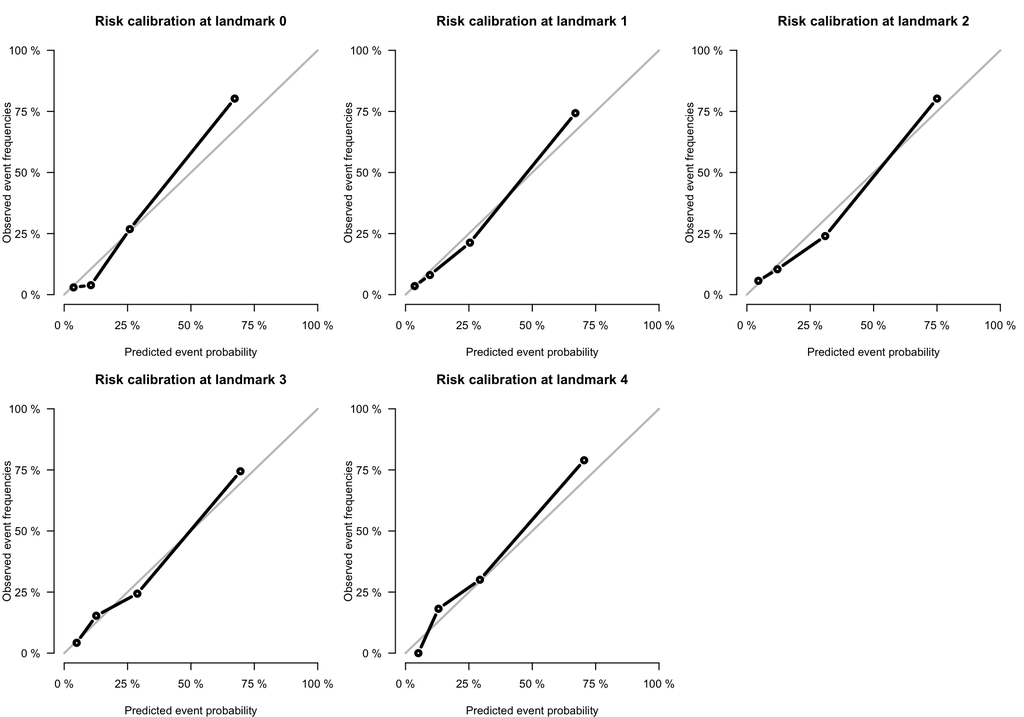

```r
old_parameters <- par(mfrow = c(2, 3), mar = c(4, 4, 3, 1))
enrollment_calibration_arguments <- list(
  object = list("Enrollment scale" = enrollment_predictions),
  times = enrollment_landmarks,
  id_col = "id",
  cause = cause_of_interest,
  method = "quantile",
  q = 4,
  legend = FALSE,
  xlim = c(0, 1),
  ylim = c(0, 1)
)
enrollment_calibration_record <- capture_conditions(do.call(
  calplot,
  enrollment_calibration_arguments
))
par(old_parameters)
```

```r
if (inherits(enrollment_calibration_record$value, "error")) {
  stop(
    "Enrollment calibration failed: ",
    conditionMessage(enrollment_calibration_record$value)
  )
}
```

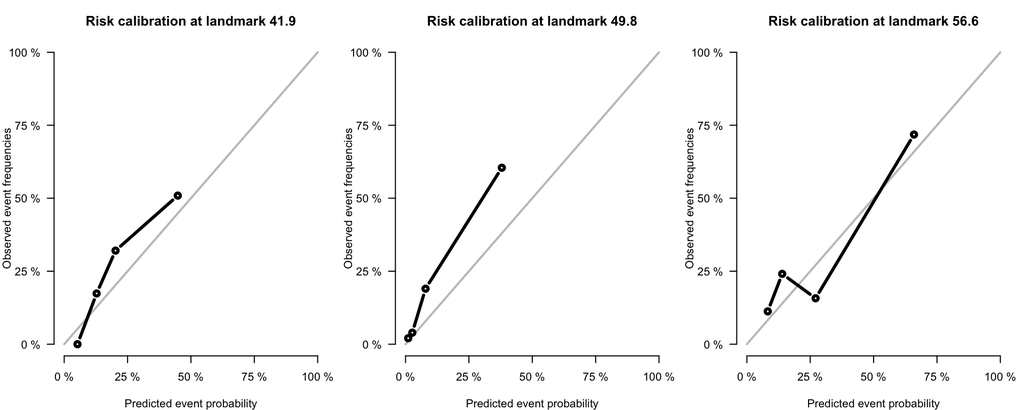

```r
old_parameters <- par(mfrow = c(1, 3), mar = c(4, 4, 3, 1))
age_calibration_arguments <- list(
  object = list("Age scale" = age_predictions),
  times = age_landmarks,
  id_col = "id",
  cause = cause_of_interest,
  method = "quantile",
  q = 4,
  legend = FALSE,
  xlim = c(0, 1),
  ylim = c(0, 1)
)
age_calibration_record <- capture_conditions(do.call(
  calplot,
  age_calibration_arguments
))
```

```r
par(old_parameters)

if (inherits(age_calibration_record$value, "error")) {
  stop(
    "Age calibration failed: ",
    conditionMessage(age_calibration_record$value)
  )
}
```

```r
calibration_conditions <- data.frame(
  scale = c("Enrollment time", "Attained age"),
  warning_count = c(
    length(enrollment_calibration_record$warnings),
    length(age_calibration_record$warnings)
  ),
  error = c(
    if (inherits(enrollment_calibration_record$value, "error")) conditionMessage(enrollment_calibration_record$value) else "",
    if (inherits(age_calibration_record$value, "error")) conditionMessage(age_calibration_record$value) else ""
  ),
  row.names = NULL
)

knitr::kable(calibration_conditions)
```

| scale | warning_count | error |
| --- | --- | --- |
| Enrollment time | 0 |  |
| Attained age | 0 |  |

# 12 Interpretation

The enrollment analysis used a common origin and updated attained age as a predictor. The attained-age analysis used age as the clock, excluded age from the right-hand side, and enforced observation by each landmark. The substantive non-age covariates and the two laboratory interaction structures were identical. The enrollment supermodel additionally included estimable centered LM main effects. The primary attained-age supermodel did not: its non-overlapping windows made LM constant within every event risk set, and the demonstration fit returned non-estimable LM coefficients.

The age-scale risk-set pattern illustrated the practical difference: people could enter as age advanced, so a later age landmark could contain more eligible subjects than an earlier one. Strict entry made that membership rule explicit.

The disjoint fits showed the cost of spending a full coefficient vector at each landmark. I retained every warning and non-estimable coefficient in the output, and I left unavailable predictions missing rather than changing a sparse model. The bootstrap likewise reports the number of complete resample-and-test pairs for every model and landmark, so the corrected performance estimates can be read together with their failure counts.

The bootstrap diagnosis traced the low attained-age completion rate to sparse transplant fits, not duplicated bootstrap identifiers or whole-replicate loss. Because the death cumulative incidence depends on the transplant hazard, a non-finite transplant fit invalidated predictions from the shared age supermodel. I therefore treated the corrected attained-age performance as conditional and exploratory rather than as a primary estimate.

This attained-age comparison cannot demonstrate smoothing of the laboratory effects. Its disjoint windows give each landmark a separate baseline, and its quadratic laboratory basis is effectively saturated over the observed age landmarks. On this grid, the attained-age supermodel pools male sex, disease stage, and treatment; a denser overlapping grid would be needed to study the additional pooling available from an LM main effect and smoother laboratory trajectories.

Within-window delayed entry was not part of this primary comparison. In the separate NAFLD application, it added very little analyzable longitudinal information because most later entrants lacked a laboratory value at their analysis entry. That finding supports treating strict entry as the clearer primary analysis rather than assuming delayed entry will automatically recover substantial usable data.